# Day 3: Latent geometry, from distance to the factor model

- Show All Code
- Hide All Code
- View Source

Advanced Network Analysis · ICPSR

Author

Shahryar Minhas

Published

July 22, 2026

**NoteHow to use this document**

Open the Day 3 teaching deck.

Everything in here runs. There is no separate script; this *is* the script, with the reasoning left in. Read it top to bottom in class; re-run any chunk against the warm cache afterwards and you will get the same numbers, because everything is seeded at `6886`. One habit: after restarting R, always run the setup chunk first: skip it and some model functions (`ergmm()` among them) complain about a missing `.Random.seed` object, which looks like a failure and is not.

The expensive model fits are wrapped in `cache_fit()`, which stores them in `cache/`. The first person to run a chunk pays for the fit; everyone after loads it in milliseconds. The slow ones: the three trade AME fits in Section 8 at roughly 30 seconds each, the four-chain convergence check in the same section at about 50 seconds (it runs its chains in parallel), and the dimension-selection loop in Section 10’s collapsed callout at about a minute, so a fully cold document costs three to four minutes of fitting, once, total. Change the model code and the cache notices and refits. Delete `cache/` to force honest refits of everything.

`lame` (the factor-model workhorse) comes from GitHub; everything else is on CRAN:

```r
install.packages(c("latentnet", "sna", "netify", "ggplot2", "reshape2",
                   "patchwork", "ggrepel", "plyr", "gridExtra", "coda",
                   "digest", "posterior", "remotes"))
remotes::install_github("s7minhas/lame")
packageVersion("lame")   # This document was built against 1.3.2. If the
                         # line above hands you something older, tell me
                         # and I will point you at the course build --
                         # a few of today's chunks lean on 1.3.2 fixes.
```

**Where this day sits on the map.** The whole course is one question: *dyadic observations are not independent; where do you put the dependence?* Yesterday represented it with **additive actor effects** (the SRM) and **discrete group structure** (the blockmodel). Today fills the richest latent-effects cell with **continuous latent geometry**. These terms enter the conditional mean or link; averaging over them induces dependence among dyads that share actors. We will meet two geometries: a distance and a factorization, and by mid-afternoon you will have seen, on data where we know the truth, why the second contains the first and not the other way around.

# 1 Where we are: geometry enters the latent effects

Yesterday was one day with two halves, and both halves matter this morning.

**The SRM half** took the one thing that is wrong with running a regression on dyads, namely that the rows are not independent, and gave the dependence a place to live: a sender effect $a_i$, a receiver effect $b_j$, a reciprocity correlation $\rho$. It fixed first- and second-order dependence, and then it failed one test, badly: the observed trade network had a transitivity the model missed by nearly **ten** posterior-predictive standard deviations. Additive effects cannot build a triangle, because a triangle needs to know *who the third actor is*.

**The blockmodel half** was one answer: sort actors into discrete groups and let ties depend on the groups. That buys third-order structure: “block 1 ties to block 2” is a statement about the whole group, and it introduced an idea we will lean on hard today, **stochastic equivalence**: two actors are equivalent if they tie to *the same others*, whether or not they tie to each other.

Today is the continuous answer to the same failure. Instead of a handful of boxes, every actor gets a **position in a continuous latent space**, and the model’s theory of tie formation is geometric. The day has a deliberate shape:

1. First, the cleanest version of the idea: the **latent distance model**: closer = more likely to tie. It is the best on-ramp to latent-space thinking ever built, you will meet it constantly in published work, and it tends to produce clustered triads.
2. Then we break it. Not rhetorically: on simulated data where we know the truth, we will watch a two-dimensional distance model miss a sharp role pattern the blockmodel handled directly.
3. Then the repair: the **latent factor model** (and its full form, **AME**), which can represent distance-like and role-based patterns in one low-rank surface. Hoff’s (2007) formal containment result is precise about what that means; our simulations illustrate the intuition rather than claiming to prove the theorem from two fitted examples.

> The dependence is real; you have to decide where to put it. Yesterday put it in additive effects and discrete blocks. Today puts it in continuous geometry, and the question of the day is *which* geometry is rich enough.

## 1.1 The Political Science Question Behind the Geometry

Imagine an alliance network. Democracies may ally with democracies, nearby states may face common threats, and powerful states may attract partners. Even after those observed covariates enter the model, alliances can remain patterned because some strategic alignments are difficult to measure directly.

A latent model asks whether a lower-dimensional relational structure helps account for what remains. The substantive possibilities are different:

- **Proximity:** states with similar unobserved strategic positions are more likely to ally.
- **Roles:** a security provider and a dependent partner may be compatible precisely because they occupy different positions.
- **Adjustment:** the latent term may be included mainly to keep residual network structure from distorting an observed covariate association.
- **Substantive measurement:** the latent structure itself may be the target, as with ideal points or strategic blocs.

Those uses require different interpretation. A useful predictive map is not automatically a causal confounder adjustment, and a latent axis is not automatically a measured political ideology.

## 1.2 The Applied Model Compass

| Model | Question we want to understand | How the model helps | What makes it distinct | A human interpretation |
| --- | --- | --- | --- | --- |
| Additive SRM | Are persistent sender and receiver tendencies enough to explain the remaining dependence? | Adjusts the conditional mean for actor activity, popularity, and reciprocity | Adds actor heterogeneity without a latent relational geometry | “Some states consistently send or receive more ties, but the model still misses patterned compatibility among particular pairs.” |
| Latent distance model | Can unobserved social or strategic proximity summarize who connects? | Infers a map in which nearby actors have higher tie probability | Uses symmetric metric proximity, which is intuitive but favors similarity over complementary roles | “These states have similar fitted alliance profiles and therefore sit near one another; the axes themselves are not named political dimensions.” |
| Latent factor or eigenmodel | Do actors connect through latent similarity, complementary roles, or both? | Builds a low-rank relational surface from sender and receiver profiles | Inner products can represent both assortative and disassortative structure compactly | “The fitted surface places these actors in compatible relational roles even though their raw factor coordinates are not uniquely interpretable.” |
| AME | Do observed covariates retain their association after additive actor effects, reciprocity, and latent pairwise structure are represented together? | Combines the SRM and multiplicative relational surface in one conditional-mean model | Separates additive heterogeneity from residual low-rank compatibility | “Shared institutions remain associated with trade after accounting for broad exporting, importing, reciprocity, and patterned residual compatibility.” |

The model should follow the applied target. Use distance when proximity is itself a defensible representation. Use factors when complementary roles matter. Use the full AME when the goal is an observed covariate association that is honest about both actor and pairwise dependence.

## 1.3 How Latent-Model Estimation Works

Both model families run the generative story backward: observed ties go in, and the algorithm finds coefficients and latent quantities that make those ties plausible.

### 1.3.1 Latent-Distance Estimation

1. **Specify the tie model.** Observed covariates enter the linear predictor, while greater latent distance lowers tie probability.
2. **Choose a dimension and prior structure.** Two dimensions make a readable map, but that choice is a modeling restriction rather than a fact found in the data.
3. **Initialize coefficients and actor positions.** Different starts can land in different local modes.
4. **Update coefficients conditional on positions, then positions conditional on coefficients.** MCMC repeats these conditional updates and retains draws after burn-in.
5. **Resolve arbitrary orientation for comparison.** Translation, rotation, and reflection do not change distances. Procrustes alignment removes those arbitrary differences without rescaling the map.
6. **Check mixing and fit.** Stable traces are necessary, then posterior predictive checks determine whether the fitted geometry reproduces degree, reciprocity, and triadic features.

### 1.3.2 Factor and AME Estimation

1. **Specify additive and multiplicative pieces.** Sender effects, receiver effects, reciprocity, and $u_i^{\mathsf T}v_j$ answer different parts of the dependence problem.
2. **Choose a candidate rank $R$.** Rank controls the complexity of the fitted relational surface.
3. **Initialize $\beta$, actor effects, factor matrices, and variance parameters.** Fast alternating least squares can provide an exploratory point estimate; MCMC supplies posterior uncertainty.
4. **Cycle through conditional updates.** Given the current factors, update coefficients and additive effects. Given those quantities, update sender and receiver factors. Then update variance and reciprocity parameters.
5. **Interpret the fitted surface before raw factors.** The product $UV^{\mathsf T}$ enters the linear predictor and is identified more directly than a particular orientation or scaling of $U$ and $V$.
6. **Compare ranks and seeds, then validate out of sample or by simulation.** A more flexible rank is useful only if its improvement is stable and substantively relevant.

The code later is compact because the package manages this loop. The loop still determines what the output means.

## 1.4 Baby MCMC for Latent Models

MCMC is easier to understand if we imagine the latent map as a seating chart we are trying to reconstruct from observed relationships. We do not know the map, the covariate effects, the actor effects, or the amount of unexplained variation. All of them have to be learned together.

The computer begins with a provisional story. It places the actors somewhere, chooses provisional coefficients, and calculates how plausible the observed ties would be. It then takes turns:

1. Holding the current map or factor surface fixed, update the covariate and additive actor effects.
2. Holding those updated effects fixed, sample a new plausible actor position or factor profile conditional on its observed relationships.
3. Update reciprocity and variance quantities.
4. Record the complete current state and repeat the cycle.

One recorded state is a **posterior draw**. A sequence of draws is the **chain**. The chain is not collecting new actors or new networks. It is revisiting plausible explanations of the same observed network. Because each state grows out of the preceding state, neighboring draws are correlated.

We discard early **burn-in** draws that may still reflect the arbitrary starting configuration. We inspect **trace plots** to see whether retained draws move around a stable region. We use **effective sample size** to ask how much independent Monte Carlo information the correlated chain contains. With multiple chains, $\widehat R$ asks whether different starting points reached the same posterior region.

Latent models add one wrinkle: several maps or factor orientations can imply the same fitted tie probabilities. A chain can rotate or reflect a distance map without changing the model. That is an identification issue, not failed mixing, and it is why we align distance maps and interpret fitted distances or the AME surface before trying to name raw axes.

The practical output is a distribution of plausible coefficients, maps, and relational surfaces. Posterior means summarize that distribution; credible intervals summarize uncertainty under the model. Running the chain longer can reduce Monte Carlo error. It cannot add actors, repair weak measurement, or turn a latent association into a causal effect.

# 2 The distance idea: a map you can predict from

Start with no political science at all. Suppose I hand you a map: forty points scattered on a page, and I tell you these points are *people*, and two people who sit close together on the map are likely to be friends. I have not told you who is friends with whom. Could you guess?

Of course you could. You would connect the clusters and leave the far-apart pairs alone. That intuition, **proximity in some space predicts ties**, is the entire latent distance model. The only thing the model adds is that it does not need me to hand it the map. It *infers* the map from the ties.

Let us make the intuition concrete by running it forwards: put points in a space ourselves, and let the space generate a network. Keep this simulated network in mind; it comes back in Section 7 as one of the two test cases.

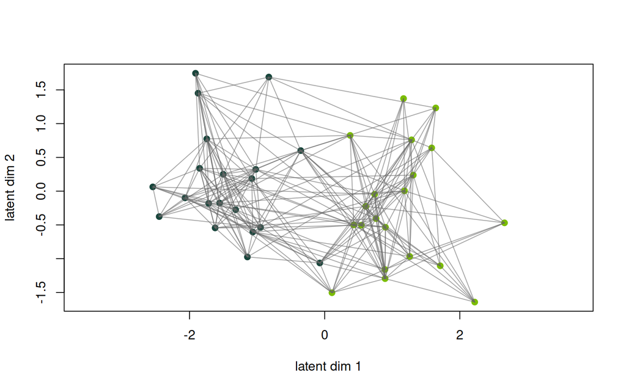

A network generated from latent positions. Two loose groups on the left/right; points that sit close tie, points that sit far do not. The model we fit later runs this picture in reverse: ties in, positions out.

```r
set.seed(6886)
np  <- 40
grp <- rep(c("group A", "group B"), each = np / 2)

# Every node gets a hidden 2-D position. Group A sits left, B sits right,
# but they overlap; this is not two clean clusters.
Z_true <- cbind(
  ifelse(grp == "group A", -1.1, 1.1) + rnorm(np, 0, 0.6),
  rnorm(np, 0, 0.8)
)

# Closer in the space -> higher tie probability. That is the whole model:
# a baseline minus the distance between the two points.
D  <- as.matrix(dist(Z_true))
P  <- plogis(2 - 1.6 * D)
# plogis() = inverse-logit: turns the log-odds into a tie probability in (0,1)
Y  <- (matrix(runif(np^2), np, np) < P) * 1  # Flip a weighted coin for each pair: tie with probability P
Y[lower.tri(Y, diag = TRUE)] <- 0          # Undirected: keep upper triangle
Y  <- Y + t(Y)

plot(Z_true, col = ifelse(grp == "group A", "#18453B", "#7BBD00"),
     pch = 19, xlab = "latent dim 1", ylab = "latent dim 2", asp = 1)
for (i in 1:np) for (j in 1:np) if (Y[i, j] == 1)
  segments(Z_true[i,1], Z_true[i,2], Z_true[j,1], Z_true[j,2],
           col = adjustcolor("grey40", 0.35))
```

The picture is exactly the intuition: dense wiring inside each blob, thin wiring across the gap. We can put a number on it: tie density among pairs that are close in the latent space versus pairs that are far:

```r
close <- D[upper.tri(D)] < median(D[upper.tri(D)])
ties  <- Y[upper.tri(Y)]
checkpoint(
  density_when_close = mean(ties[close]),
  density_when_far   = mean(ties[!close])
)
```

```
#> ------------------------------------------------------------------
#> CHECKPOINT: density_when_close = 0.523   |   density_when_far = 0.095
#> ------------------------------------------------------------------
```

Close pairs tie at 0.52; far pairs at 0.09. Distance in the latent space is doing all the work.

Now notice what this tends to buy us. Distances obey the **triangle inequality**:

$$\lVert u_i-u_k\rVert \leq
\lVert u_i-u_j\rVert + \lVert u_j-u_k\rVert.$$

That does **not** make closeness literally transitive. Two short legs can add up to a third leg that is longer than either one, and an observed tie is only a probabilistic clue about distance. What the inequality does is constrain the third distance: if $i$ is very near both $j$ and $k$, then $j$ and $k$ cannot be arbitrarily far apart. Because tie probability falls with distance, latent homophily therefore raises the probability of clustered and transitive configurations. It makes triangles common in expectation; it does not force every open two-path to close. That probabilistic version is the structural reason this model exists, and Section 4 shows the trade-off that comes with it.

## 2.1 The model, written down

The model just says what the picture said. For an undirected binary tie $y_{ij}$:

$$\text{logit}\, \Pr(y_{ij} = 1)
\;=\; \alpha + \underbrace{\beta^\top x_{ij}}_{\text{covariates}}
\;-\; \underbrace{\lVert u_i - u_j \rVert}_{\substack{\text{distance between}\\\text{latent positions}}}$$

Read it slowly. Each actor $i$ gets a position $u_i$ in a $d$-dimensional space (often $d = 2$, so you can draw it). The further apart two actors sit, the *more* we subtract from the log-odds of a tie. The $\beta^\top x_{ij}$ part is a regression on measured dyadic or nodal covariates; the geometry represents residual structure those covariates do not explain. This is Hoff, Raftery & Handcock’s (2002) latent space model, and it is what `latentnet::ergmm()` fits.

**NoteWhat the likelihood is doing, and where actor activity lives**

Conditional on the positions and covariates, the basic undirected binary LDM treats the unordered dyads as independent Bernoulli observations:

$$p(Y\mid U,X,\alpha,\beta)
= \prod_{i<j} p_{ij}^{y_{ij}}(1-p_{ij})^{1-y_{ij}},
\qquad
\operatorname{logit}(p_{ij})
= \alpha+\beta^\top x_{ij}-\lVert u_i-u_j\rVert.$$

Three details matter. First, the product is over $i<j$, so an undirected dyad is counted once. Second, one observed tie does not tell us that two actors are close. The map is learned from each actor’s *whole pattern* of ties. Third, the basic distance term can create some degree variation indirectly: an actor near the middle of the cloud may be close to many others. It does not give every actor a free activity parameter, however. If residual degree heterogeneity remains, add a random sociality term such as `rsociality()` for an undirected `ergmm()` fit, or use AME’s additive $a_i+b_j$ terms. Geometry and activity are different jobs, even when a fitted map partly performs both.

Compare it to where the SRM stopped yesterday:

$$y_{ij} \approx \beta^\top x_{ij} + a_i + b_j
+ \underbrace{\gamma(u_i, u_j)}_{\text{today's blank to fill}}
+ \varepsilon_{ij}$$

The whole day is a fight over what to write in the $\gamma$ slot. The distance model’s proposal is $\gamma(u_i,u_j) = -\lVert u_i - u_j\rVert$. It will not be the winning proposal, but it is the right one to meet first.

**ImportantThe one sentence for this section**

**An actor’s position is a compression of its entire tie profile into a handful of coordinates**, and closeness in those coordinates is the model’s theory of why ties are more likely. The geometry represents latent homophily and tends to generate transitive clustering, without making any single tie or triangle deterministic.

# 3 The cameo: one `ergmm()` fit you must recognize

You will meet this model *constantly* in published work: alliance politics, legislative collaboration, friendship networks, and trade, usually as a two-dimensional map with actor labels, fit with `latentnet::ergmm()`. So you need to have fit one, once, and you need to know how to read the plot (and, after Section 5, how *not* to). That is the scope of this section: a cameo, not a lab. The modeling muscle of the day goes to the model that supersedes it.

Our data: a cross-section of **defense alliances**. 49 states, an undirected tie if two states share an alliance.

```r
# Self-contained: everything is in this day's own data/ folder.
# (The file name keeps an older course numbering; it IS today's data.)
load("data/day11_distance.rda")   # allyV, allyEL, contig (+ two prefit models)

AllyNet <- network.initialize(nrow(allyV), directed = FALSE)
network.vertex.names(AllyNet) <- allyV$stateabb
AllyNet[as.matrix(allyEL)] <- 1                       # Add the edges

# A nodal covariate: polity, standardized so its coefficient is per-sd
set.vertex.attribute(AllyNet, "polity", allyV$polity / sd(allyV$polity))

checkpoint(
  n_states     = network.size(AllyNet),
  n_ties       = network.edgecount(AllyNet),
  density      = network.density(AllyNet),
  transitivity = gtrans(AllyNet)
)
```

```
#> ------------------------------------------------------------------
#> CHECKPOINT: n_states = 49   |   n_ties = 108   |   density = 0.092   |   transitivity = 0.829
#> ------------------------------------------------------------------
```

Hold onto that transitivity of 0.829: the fraction of two-paths that close into triangles, the same *kind* of statistic that broke the SRM on the trade network yesterday.

The fit is one line. We ask for a network model whose only structural term is a 2-dimensional Euclidean latent space. On a cold run, this fit takes about 10 seconds; it ships cached and reloads instantly.

```r
ls2d <- cache_fit("ls2d", ergmm(
  AllyNet ~ euclidean(d = 2),
  control = ergmm.control(sample.size = 4000, interval = 10,
                          burnin = 10000),
  seed = 6886, verbose = FALSE
))
```

This is MCMC, so the discipline from Day 2 applies before we look at anything pretty: check that the chain went somewhere. One line: trace and density plots plus the autocorrelation printout:

```
#> Chain 1
#> Lag 0
#>               lpY       beta.1         Z.1.1       Z.1.2
#> lpY    1.00000000 5.653112e-01  3.640342e-02  0.02207160
#> beta.1 0.56531119 1.000000e+00  2.130241e-06  0.05496838
#> Z.1.1  0.03640342 2.130241e-06  1.000000e+00 -0.01060411
#> Z.1.2  0.02207160 5.496838e-02 -1.060411e-02  1.00000000
#>
#> Lag 10
#>               lpY     beta.1      Z.1.1      Z.1.2
#> lpY    0.41015207 0.31266336 0.03144163 0.01360199
#> beta.1 0.31137326 0.39275861 0.02051556 0.04082953
#> Z.1.1  0.04293191 0.02423710 0.71570459 0.08168753
#> Z.1.2  0.01640021 0.02996113 0.06717210 0.76243123
```

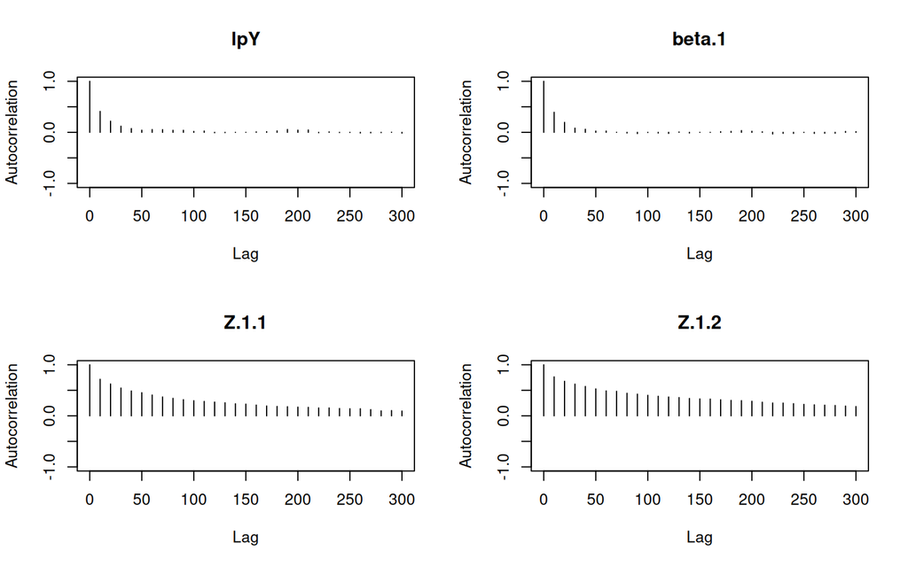

[figure not shown]

MCMC diagnostics for the cameo fit. Fuzzy, stable caterpillars on the left; smooth unimodal densities on the right. If yours look like a staircase or a two-humped camel, run the chain longer before believing any map.

```
#> [[1]]
#>
#> Quantile (q) = 0.025
#> Accuracy (r) = +/- 0.0125
#> Probability (s) = 0.95
#>
#>         Burn-in  Total Lower bound  Dependence
#>         (M)      (N)   (Nmin)       factor (I)
#>  lpY    40       8130  600          13.6
#>  beta.1 30       7170  600          12.0
#>  Z.1.1  100      18260 600          30.4
#>  Z.1.2  100      17760 600          29.6
```

```r
mcmc.diagnostics(ls2d)
```

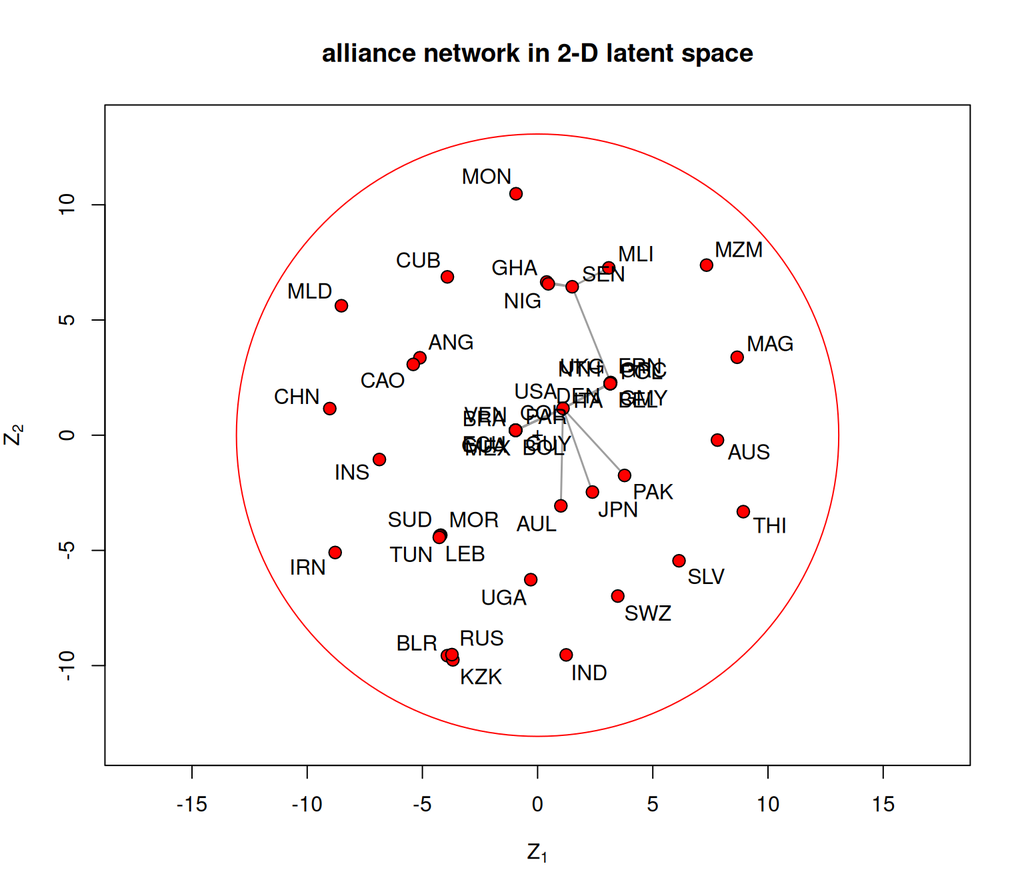

The estimated latent space. Each state is placed at its inferred position; ties are drawn between them. States that cluster are states the model thinks are close, meaning they are likely to be allied. This is the canonical latent-space figure; when you see one in a paper, this is what produced it.

```r
plot(ls2d, labels = TRUE, print.formula = FALSE,
     main = "alliance network in 2-D latent space")
```

Read it the way you read the simulated picture: tight clusters are sets of states the model believes are mutually close, and closeness is its explanation for their alliances. The intercept sits at 6.82, the baseline log-odds of a tie before distance is subtracted. That number comes from `summary()`, which is also the table you would put in a paper: posterior means, quantiles, and a BIC block whose printed caveat (that it is a rough guide for dimension selection, not a law) you should take at face value:

```r
summary(ls2d)
```

```
#>
#> ==========================
#> Summary of model fit
#> ==========================
#>
#> Formula:   AllyNet ~ euclidean(d = 2)
#> Attribute: edges
#> Model:     Bernoulli
#> MCMC sample of size 4000, draws are 10 iterations apart, after burnin of 10000 iterations.
#> Covariate coefficients posterior means:
#>             Estimate   2.5%  97.5% 2*min(Pr(>0),Pr(<0))
#> (Intercept)   6.8191 4.9564 9.1276            < 2.2e-16 ***
#> ---
#> Signif. codes:  0 '***' 0.001 '**' 0.01 '*' 0.05 '.' 0.1 ' ' 1
#>
#> Overall BIC:        727.0119
#> Likelihood BIC:     127.7895
#> Latent space/clustering BIC:     599.2223
#>
#> Covariate coefficients MKL:
#>             Estimate
#> (Intercept) 2.026461
```

It is a genuinely useful picture and a readable table, and in Section 5 I will prove you are not allowed to believe half of what you see on the picture.

And before we break this model, watch it *win* the kind of fight the SRM lost. The geometry is supposed to manufacture triangles, so does it? Simulate networks straight from the cameo’s posterior (one per stored draw: each draw’s tie probabilities are just `plogis(beta - distance)`; we build the simulation by hand rather than call `simulate()`, for a reason Section 4 explains) and measure their transitivity:

```r
set.seed(6886)
draw_ids <- round(seq(1, dim(ls2d$sample$Z)[1], length.out = 100))
tr_sim <- sapply(draw_ids, function(s) {
  Pm <- plogis(ls2d$sample$beta[s] - as.matrix(dist(ls2d$sample$Z[s, , ])))
  n  <- nrow(Pm)
  Ys <- (matrix(runif(n^2), n, n) < Pm) * 1
  Ys[lower.tri(Ys, diag = TRUE)] <- 0
  Ys <- Ys + t(Ys)
  gtrans(Ys)
})
checkpoint(
  observed_transitivity = gtrans(AllyNet),
  ldm_simulated_mean    = mean(tr_sim),
  no_geometry_baseline  = network.density(AllyNet)  # ER graph: transitivity ~ density
)
```

```
#> ------------------------------------------------------------------
#> CHECKPOINT: observed_transitivity = 0.829   |   ldm_simulated_mean = 0.75   |   no_geometry_baseline = 0.092
#> ------------------------------------------------------------------
```

A model with *no* geometry, with ties flipped independently at the observed density, produces transitivity near 0.09. The distance model’s posterior produces 0.75, most of the way to the observed 0.83, and roughly eight times the no-geometry baseline. The triangle inequality is doing exactly what Section 2 promised: nearby neighborhoods make triangle closure more probable. The result is strong in this fit, but neither closeness nor closure is deterministic. Hold that win in mind: the next section is the same geometry struggling with a different pattern.

**NoteThe full `ergmm()` toolbox, when you need it in your own work (self-study)**

Because this is a cameo, the core path stops here. But if the distance model turns out to be *your* tool, the rest of the workflow is one-liners, and they all run: open this box after class:

```r
# Dimension selection: the BIC from the summary table, as a number you
# can compare across d = 1, 2, 3 refits (Krivitsky & Handcock 2008).
bic.ergmm(ls2d)$overall
```

```
#> [1] 727.0119
```

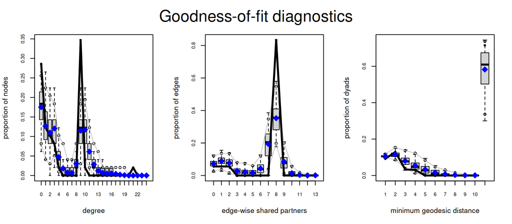

Posterior-predictive GOF for the cameo: degree distribution, edgewise shared partners, and geodesics. Observed as the dark line, simulated as boxplots: the same simulate-and-compare logic as this afternoon’s gof_plot().

```r
# Posterior-predictive gof. One namespacing footnote: lame also exports
# a gof(), and it wins the dispatch once library(lame) is attached --
# so call the ergm generic explicitly:
ally_gof <- ergm::gof(ls2d, GOF = ~ degree + espartners + distance)
par(mfrow = c(1, 3)); plot(ally_gof)
```

```r
# The model's expected tie probabilities (posterior mean), an n x n
# matrix: the same "what does the model think this dyad is" question
# predict() answers for ame fits in @sec-gof:
round(predict(ls2d)[1:4, 1:4], 2)
```

```
#>      [,1] [,2] [,3] [,4]
#> [1,] 1.00 0.00    0    0
#> [2,] 0.01 1.00    0    0
#> [3,] 0.01 0.01    1    0
#> [4,] 0.00 0.07    0    1
```

What this box still is not running: dyadic and nodal covariates enter via `edgecov()`/`nodecov()` (homophily entered as a distance, e.g. regime similarity predicting alliances); model-based clustering on top of the space is `euclidean(d = 2, G = k)` (Handcock, Raftery & Tantrum 2007), which you will see run on the foil network later this morning. And one bridge worth knowing about is that `latentnet` has a `bilinear()` term, the factor-model idea living *inside* `ergmm()`. This afternoon is essentially that term promoted to the whole model. If the distance model is the right tool for your question, the Krivitsky & Handcock software paper in the readings is the manual.

**NoteA neutral non-alliance dataset, if IR is not your world**

Half this room does not study alliances, and nothing today needs them. `latentnet` ships a canonical latent-space teaching set you can swap in with no other change, use the Sampson monastery data. Run `data(sampson)`, which binds an object called **`samplike`** (18 monks and who-nominated-whom). It is a *directed* network, so read it as who-likes-whom; the model runs on it exactly as written: `ergmm(samplike ~ euclidean(d = 2))`, and everything today follows, with “monks” for “states” throughout. (The object is named `samplike`, not `sampson`; `data(sampson)` is only the loader.)

# 4 Where the map breaks

Now the honest part. The same geometry that favors clustered ties makes a **low-dimensional** distance model an awkward language for sharp disassortative roles. If two actors have nearly identical tie profiles but do not tie to each other, a one-map distance model faces a tension: similar profiles encourage similar locations, while similar locations also raise their direct tie probability. A factor or block model can separate those two ideas cleanly.

This is a representational and parsimony claim, not an absolute impossibility claim. With enough dimensions, a finite Euclidean configuration can mimic more structure than a two-dimensional picture suggests. Hoff (2007) shows that doing so for role structure can require dimension that grows with the pattern being represented. The practical question is whether the small $d$ we can estimate and interpret represents the pattern compactly. Rather than answer in the abstract, build a network that puts that small model under stress: two groups, ties almost always *between*, almost never *within*, as in a buyer-seller or patron-client system.

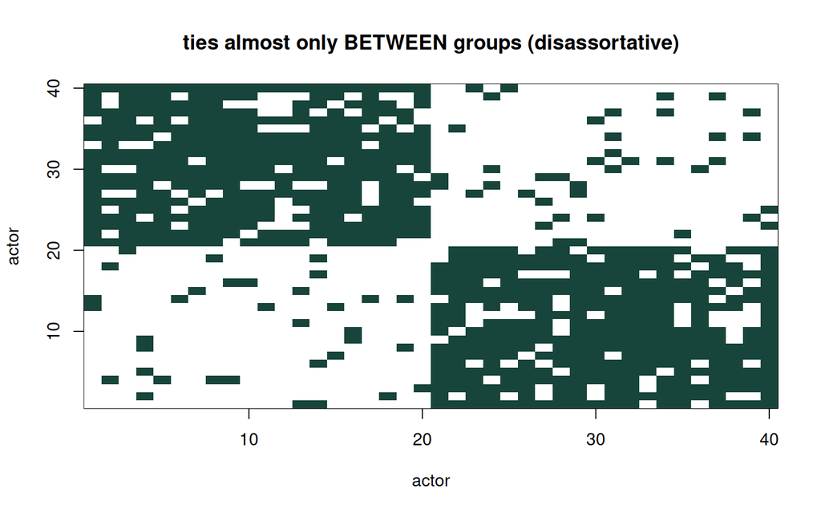

The disassortative test network. Ties (dark cells) run almost entirely BETWEEN the two groups. To make between-group pairs likely, a distance model must put them close, but then within-group pairs get dragged close too, and it predicts within-group ties that do not exist.

```r
set.seed(6886)
same  <- outer(grp, grp, "==")
Pdis  <- ifelse(same, 0.10, 0.85)
Ydis  <- (matrix(runif(np^2), np, np) < Pdis) * 1
Ydis[lower.tri(Ydis, diag = TRUE)] <- 0
Ydis  <- Ydis + t(Ydis)
diag(same) <- NA
image(1:np, 1:np, Ydis, col = c("white", "#18453B"),
      xlab = "actor", ylab = "actor",
      main = "ties almost only BETWEEN groups (disassortative)")
```

```r
obs_within  <- mean(Ydis[same],  na.rm = TRUE)
obs_between <- mean(Ydis[!same], na.rm = TRUE)
checkpoint(
  observed_within_group_density  = obs_within,
  observed_between_group_density = obs_between
)
```

```
#> ------------------------------------------------------------------
#> CHECKPOINT: observed_within_group_density = 0.097   |   observed_between_group_density = 0.815
#> ------------------------------------------------------------------
```

The truth is stark: within-group density 0.1, between-group density 0.81. Now fit the latent distance model to this network, using the same one-liner as the alliance fit, about 5 seconds on a cold run and shipped cached, and ask the fitted model what *it* thinks those two densities are, reading tie probabilities straight off its posterior draws (each draw is an intercept and a set of positions, so each draw is a full matrix of `plogis(beta - distance)` probabilities).

```r
ldm_dis <- cache_fit("ldm_dis", ergmm(
  network(Ydis, directed = FALSE) ~ euclidean(d = 2),
  control = ergmm.control(sample.size = 2000, interval = 10,
                          burnin = 5000),
  seed = 6886, verbose = FALSE
))
pp <- sapply(seq_len(dim(ldm_dis$sample$Z)[1]), function(s) {
  Pm <- plogis(ldm_dis$sample$beta[s] -
               as.matrix(dist(ldm_dis$sample$Z[s, , ])))
  c(within  = mean(Pm[same],  na.rm = TRUE),
    between = mean(Pm[!same], na.rm = TRUE),
    overall = mean(Pm[row(Pm) != col(Pm)]))
})
checkpoint(
  ldm_predicted_within  = mean(pp["within", ]),
  ldm_predicted_between = mean(pp["between", ]),
  observed_within       = obs_within,
  observed_between      = obs_between
)
```

```
#> ------------------------------------------------------------------
#> CHECKPOINT: ldm_predicted_within = 0.461   |   ldm_predicted_between = 0.47   |   observed_within = 0.097   |   observed_between = 0.815
#> ------------------------------------------------------------------
```

Look at what this fitted two-dimensional model did. The observed structure is 0.1 within vs 0.81 between: about as far from uniform as a network can be. The fitted distance model predicts 0.46 within and 0.47 between: **it flattened the sharpest structure in the data into one flat number.** It cannot put the two groups far apart (they tie constantly) and it cannot put each group’s members close together without inventing within-group ties, so it smears everyone into one cloud where every pair looks the same.

And look at *where* the flat prediction landed: 0.47, which is exactly the observed overall density (0.47). The fitted cloud found a reasonable compromise for the model we actually asked for, but the compromise erased the within/between contrast that generated the data. That is the evidence here: this $d=2$ LDM does not represent this pattern well. It is not a theorem that every Euclidean model at every dimension must return this number.

**Note“Maybe the chain just needed longer”: checking, not asserting**

A fair worry, so run it: the same model with a burn-in **six times longer**, about 5 seconds on a cold run and shipped cached, pushed through the same posterior-probability computation.

```r
ldm_dis_long <- cache_fit("ldm_dis_long", ergmm(
  network(Ydis, directed = FALSE) ~ euclidean(d = 2),
  control = ergmm.control(sample.size = 2000, interval = 10,
                          burnin = 30000),
  seed = 6886, verbose = FALSE
))
pp_long <- sapply(seq_len(dim(ldm_dis_long$sample$Z)[1]), function(s) {
  Pm <- plogis(ldm_dis_long$sample$beta[s] -
               as.matrix(dist(ldm_dis_long$sample$Z[s, , ])))
  c(within  = mean(Pm[same],  na.rm = TRUE),
    between = mean(Pm[!same], na.rm = TRUE))
})
checkpoint(
  long_burnin_within  = mean(pp_long["within", ]),
  long_burnin_between = mean(pp_long["between", ])
)
```

```
#> ------------------------------------------------------------------
#> CHECKPOINT: long_burnin_within = 0.46   |   long_burnin_between = 0.469
#> ------------------------------------------------------------------
```

0.46 within, 0.47 between: the same flat map to two decimals. The short run was not hiding a better $d=2$ answer behind an unfinished chain. Changing the dimension or the model family is a separate question.

**WarningWhy compute the prediction by hand instead of calling `simulate()`?**

Because for **undirected** `ergmm` fits, `latentnet`’s (2.12) `simulate()` method double-samples every dyad: it fills the full $n \times n$ matrix with independent Bernoulli draws and then symmetrizes by OR-ing the two triangles, so a simulated tie appears if *either* of two independent coin flips came up heads: density inflated from $p$ to $1-(1-p)^2$. Check it against the model’s own probabilities:

```r
or_pred <- sapply(seq_len(dim(ldm_dis$sample$Z)[1]), function(s) {
  Pm <- plogis(ldm_dis$sample$beta[s] -
               as.matrix(dist(ldm_dis$sample$Z[s, , ])))
  mean(1 - (1 - Pm[row(Pm) != col(Pm)])^2)
})
sim20 <- simulate(ldm_dis, nsim = 20, seed = 6886)
checkpoint(
  model_mean_tie_probability = mean(pp["overall", ]),
  or_coupled_prediction      = mean(or_pred),
  simulate_mean_density      = mean(sapply(sim20$networks, network.density))
)
```

```
#> ------------------------------------------------------------------
#> CHECKPOINT: model_mean_tie_probability = 0.465   |   or_coupled_prediction = 0.692   |   simulate_mean_density = 0.691
#> ------------------------------------------------------------------
```

`simulate()`’s networks land on the OR-coupled density (0.69 vs the model’s actual 0.47), not the model’s. The moral is general and worth keeping: **never build a posterior-predictive check on machinery you have not verified against the model equation**: for undirected `ergmm` fits, compute the probabilities from the draws yourself, as we did above. (Directed fits do not hit this, because no symmetrization step exists.)

And if the positions were recovering the group structure, clustering them would find the groups. It does not:

```r
truth   <- as.integer(factor(grp))
km_ldm  <- kmeans(ldm_dis$mkl$Z, 2, nstart = 50)
acc_ldm <- max(mean(km_ldm$cluster == truth), mean(km_ldm$cluster == 3 - truth))
checkpoint(kmeans_on_LDM_positions_accuracy = acc_ldm)
```

```
#> ------------------------------------------------------------------
#> CHECKPOINT: kmeans_on_LDM_positions_accuracy = 0.55
#> ------------------------------------------------------------------
```

55%: a coin flip for this fitted summary. The true block structure is right there in the sociomatrix, but it is not recoverable from these two-dimensional point estimates with this clustering step. Remember this number: in Section 7 the factor model’s fitted surface, on the same network, separates the roles much more cleanly.

**Note“But `latentnet` can cluster”: checking the obvious comeback**

A fair objection: I clustered raw positions with k-means, and `latentnet` has its own *model-based* clustering (Handcock, Raftery & Tantrum 2007) that fits a mixture with uncertainty, a genuine published success on assortative networks. Does it rescue the foil? No, and not because of tuning: the mixture model still has to place its clusters in a Euclidean space governed by the same triangle inequality. Run it and let the output decide. The cold fit takes about 10 seconds and ships cached:

```r
hrt_dis <- cache_fit("hrt_dis", ergmm(
  network(Ydis, directed = FALSE) ~ euclidean(d = 2, G = 2),
  seed = 6886, verbose = FALSE
))
cl_hrt  <- hrt_dis$mkl$Z.K            # The model-based cluster assignments
acc_hrt <- max(mean(cl_hrt == truth), mean(cl_hrt == 3 - truth))
checkpoint(clusters_found = length(unique(cl_hrt)),
           hrt_cluster_accuracy = acc_hrt)
```

```
#> ------------------------------------------------------------------
#> CHECKPOINT: clusters_found = 1   |   hrt_cluster_accuracy = 0.5
#> ------------------------------------------------------------------
```

50%: chance again; on this run the mixture puts every actor in a single cluster, because in the collapsed cloud there is nothing to separate. Model-based clustering does not rescue this particular low-dimensional distance fit.

**ImportantThe score at the half**

The distance model is built for **latent homophily** and tends to generate transitive clustering, which is exactly what the SRM lacked. A small Euclidean space can represent sharp **stochastic equivalence or disassortative mixing** very inefficiently, and this $d=2$ fit missed it completely. Yesterday’s blockmodel handled the role pattern directly. Neither tool dominates the other. What we want next is one low-rank object that can represent both kinds of structure compactly. That object is the eigenmodel in Section 6.

# 5 Reading any position plot honestly: identifiability and Procrustes

Before we replace the distance model, learn the identification problem in its cleanest form. The exact invariances in this section belong to a distance map. The factor model has the same broad warning, “the coordinates are not the estimand,” but its directed version has a larger invariance than an ordinary rotation. We handle that separately in Section 8 and Section 10.

Here is the problem, and it is not a technicality. **The model is only identified up to rotation, reflection, and translation of the latent positions.** The likelihood depends on the positions *only through the pairwise distances* $\lVert u_i - u_j \rVert$. And distances do not change if you spin the whole configuration, flip it in a mirror, or slide it across the page.

So there is not one set of positions that fits your network. There are infinitely many: every rotated, reflected, shifted copy fits *exactly as well*. The plot `latentnet` drew you in Section 3 is one arbitrary member of that infinite family.

Let us prove it, because it is easy to prove and impossible to forget once you have seen it. Take the alliance positions we just estimated, rotate them by 60 degrees, flip them, and shove them across the page. The distances, and therefore the fit and everything the model claims, are untouched.

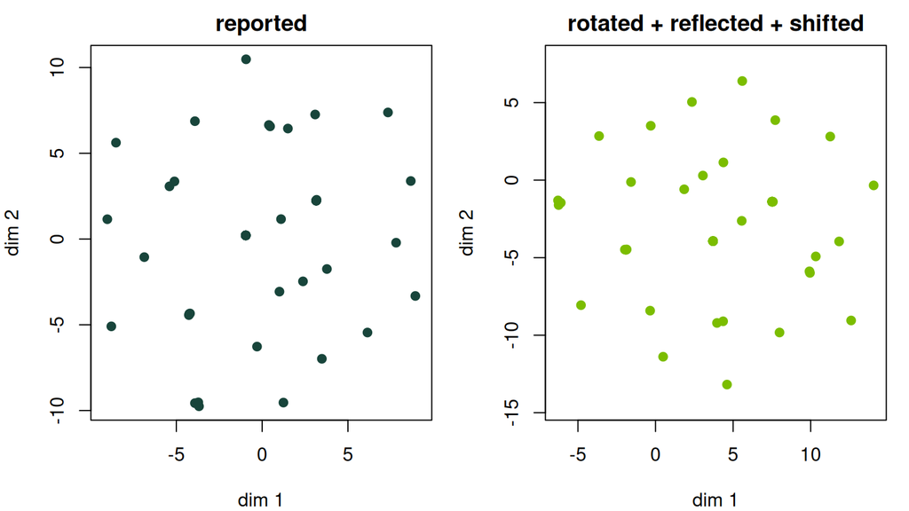

Left: the positions latentnet reported. Right: the SAME positions rotated 60 degrees, reflected, and translated. Different-looking map, identical model. Anything you ‘read off’ the axes on the left is an artifact.

```r
# ls2d$mkl$Z is latentnet's single best point-estimate of the positions; the
# MKL (minimum Kullback-Leibler) configuration, the one map it picks to
# summarize the whole posterior.
Z <- ls2d$mkl$Z

theta  <- pi / 3                          # 60 degrees
Rot    <- matrix(c(cos(theta), sin(theta), -sin(theta), cos(theta)), 2)
Reflect<- diag(c(1, -1))                  # Mirror the 2nd axis
Z_alt  <- Z %*% Rot %*% Reflect
Z_alt  <- sweep(Z_alt, 2, c(4, -3), "+")  # Translate

par(mfrow = c(1, 2), mar = c(4, 4, 2, 1))
plot(Z, pch = 19, col = "#18453B", asp = 1, main = "reported",
     xlab = "dim 1", ylab = "dim 2")
plot(Z_alt, pch = 19, col = "#7BBD00", asp = 1, main = "rotated + reflected + shifted",
     xlab = "dim 1", ylab = "dim 2")
```

The two point clouds look nothing alike. But the pairwise distance matrices are, to numerical precision, the same object:

```r
max_dist_diff <- max(abs(as.matrix(dist(Z)) - as.matrix(dist(Z_alt))))
checkpoint(
  max_abs_difference_in_all_pairwise_distances = max_dist_diff
)
```

```
#> ------------------------------------------------------------------
#> CHECKPOINT: max_abs_difference_in_all_pairwise_distances = 0
#> ------------------------------------------------------------------
```

5.3e-15. This is zero to rounding. The model literally cannot tell these two maps apart. They are the same fit wearing different clothes.

**ImportantWhat you may and may not read off a latent-space plot**

**Allowed:** who is close to whom; which actors cluster; relative distances; that a pair is far apart. These are invariant to rotation/reflection/shift.

**Forbidden:** “the x-axis is ideology.” “This actor is on the *left*.” “There is a north-south split.” Absolute directions, axis labels, and orientation are *yours*, not the data’s. If your interpretation would change under a mirror flip, it is not a finding; it is an artifact of which arbitrary map the sampler happened to hand you.

This box applies exactly to distance models. The safe habit travels to every latent model: identify which functions of the latent variables leave the likelihood unchanged, and interpret only quantities that survive those transformations.

## 5.1 So what is Procrustes?

If two maps that differ only by rotation/reflection/translation are the same model, then to *compare* two fitted maps across seeds, across models, or across your fit and a coauthor’s, you first have to strip away that arbitrary difference. That alignment step is called a **Procrustes rotation**: rotate, reflect, and shift one configuration to line up as closely as possible with a target, then look at whatever is left.

(The name comes from a Greek myth: Procrustes stretched or lopped his guests to fit an iron bed. Here we are allowed to rotate and flip a configuration but *not* stretch it; the shape is sacred, only the pose is negotiable.)

And here is the lovely part, the part that connects straight to the second half of today: the optimal Procrustes rotation is computed with a **singular value decomposition** (SVD, the same matrix factorization that powers the factor model in Section 6; if it is new, treat `svd()` as a black box that hands back the best rotation, and see the appendix at the end of the day). To align $X$ to a target $Y$ (both centered), take the SVD of $X^\top Y = U \Sigma V^\top$; the best rotation is $R = U V^\top$. That is the whole algorithm.

```r
# Align X onto target, allowing rotation + reflection + translation
# (but NOT rescaling: distances are the model, so we may not stretch them).
procrustes_align <- function(X, target) {
  Xc <- scale(X,      center = TRUE, scale = FALSE)
  Tc <- scale(target, center = TRUE, scale = FALSE)
  s  <- svd(t(Xc) %*% Tc)          # <- The SVD doing the work
  R  <- s$u %*% t(s$v)             # Optimal orthogonal (rotation/reflection)
  aligned <- Xc %*% R
  list(aligned = aligned,
       mse = mean((Tc - aligned)^2))
}
```

(One namespacing footnote before you use this outside class: `lame` exports its *own* `procrustes_align()`, a longitudinal version that aligns factor positions across time points, with a different signature. Once you run the chunk above, ours masks it for the rest of the session; before you run it, a bare call finds lame’s and hands you a confusing error. `lame::procrustes_align` always gets you the packaged one explicitly.)

Run it on our deliberately-mangled map. It should recover the original exactly, because the mangling was *only* rotation/reflection/translation; nothing Procrustes cannot undo.

```r
rec <- procrustes_align(Z_alt, Z)
mse_before <- mean((scale(Z, scale = FALSE) -
                    scale(Z_alt, scale = FALSE))^2)
checkpoint(
  mse_before_alignment = mse_before,
  mse_after_alignment  = rec$mse
)
```

```
#> ------------------------------------------------------------------
#> CHECKPOINT: mse_before_alignment = 37.567   |   mse_after_alignment = 0
#> ------------------------------------------------------------------
```

Before alignment the two maps disagree by 37.57; after Procrustes they agree to 1.2e-30, effectively machine zero. The difference between the two plots was *entirely* the arbitrary pose, and Procrustes removed all of it.

**NoteThe realistic case: two independent chains**

The demo above rotated the *same* positions, so Procrustes recovers them perfectly. Real life is messier: run the sampler twice from different seeds and you get two genuinely different point estimates, with contributions from posterior uncertainty, Monte Carlo error, weak identification, and possibly different local modes. Procrustes removes only the orthogonal pose. A residual after alignment tells you that the two summaries differ beyond that pose; it does not diagnose which of those sources caused the difference. This is exactly why `latentnet` aligns internally: `plot()` and `summary()` align every posterior draw to a common reference (the MKL configuration) *before* averaging, which is the only reason the plotted positions are stable at all. Run the two-chain version yourself as exercise 3.

**CautionThe deeper point: the manifold itself is a choice (Lubold, Chandrasekhar & McCormick 2023)**

Rotation and reflection are the *easy* part of non-identifiability; they are inside the model and Procrustes fixes them. There is a harder layer underneath.

We *chose* $d = 2$. We *chose* Euclidean distance: flat space. We *chose* a space with no curvature. None of these came from the data; we imposed them before the model saw a single tie. Lubold, Chandrasekhar & McCormick (2023, *JRSS-B*) make the uncomfortable case precise: the **dimension, the geometry, and the curvature of the latent space are *a priori* modeling assumptions**, and different manifolds can fit the same network comparably well while telling different substantive stories. A network that looks like tight clustering in flat 2-D space might be perfectly ordinary points on a sphere.

The practical discipline that follows:

- Report the dimension you chose and *why* (fit? Interpretability? A theory?).
- Do not treat a 2-D picture as “the” geometry of your network; it is the geometry *conditional on your assuming 2-D flat Euclidean space*.
- When curvature could plausibly matter (hierarchies, cores-and-peripheries), say so, and know that the tools to test it are recent and still developing.

This does not make these models useless; it makes them honest. You are fitting a map under assumptions, and naming the assumptions is the whole job. The factor model we are about to build also carries a chosen rank $R$ and an identification convention. Its directed invariance is broader than rotation, so nothing this afternoon is exempt from the habit even though the exact algebra changes.

# 6 Two kinds of “similar” + the factor model

The fix starts by naming precisely what the distance model could not say. There are two classic ways third-order structure shows up, and they are genuinely different theories of what makes two actors “alike.”

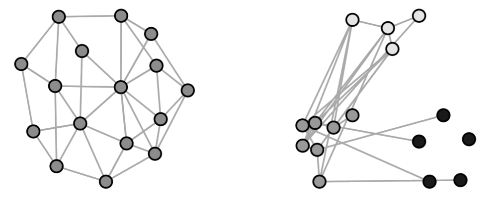

**Homophily**: birds of a feather. Actors are more likely to tie to actors who are *like them*. This is the distance story. If $i$ is very near both $j$ and $k$, the triangle inequality constrains how far apart $j$ and $k$ can be, so a decreasing-distance tie probability tends to produce clustered triads. It raises a probability; it does not turn two observed ties into a logical proof of the third.

**Stochastic equivalence**: actors occupy the same *role*: they tie to the same others *without necessarily tying to each other*. Two junior faculty both work with senior colleagues and grad students but not with each other. Belgium and the Netherlands both export to Germany and import from China, and their rows in the trade matrix look nearly identical, but the Belgium-Netherlands cell itself can be small. Yesterday’s blockmodel did this with discrete groups; Section 4’s disassortative network is its extreme case.

**Important**

Homophily says **similar actors connect to each other**. Stochastic equivalence says **similar actors connect to the same others**. The distance model is a compact language for the first; a small distance space can need many more dimensions to approximate the second. Section 4 was a concrete failure at $d=2$, not a universal impossibility proof. The multiplicative term represents both patterns compactly, and that is the whole reason it exists.

## 6.1 The multiplicative term

Replace “distance between positions” with an **inner product** of positions. If the phrase is new, here is all it means: *multiply the two actors’ coordinates dimension by dimension and add the results up.* The sum is big and positive when the two vectors point the same way, near zero when they are unrelated, and **negative when they point in opposite directions**, and that negative option is the new degree of freedom, because a distance can only ever say “far,” never “opposite.”

Start with the undirected case, since both of our simulated test networks are undirected. Each actor gets one vector $u_i$ of length $R$ (the number of dimensions you choose), and the geometry enters as the symmetric **eigenmodel** (Hoff 2007):

$$\gamma(u_i, u_j) = u_i^\top \Lambda\, u_j = \sum_{r=1}^{R} \lambda_r\, u_{i,r}\, u_{j,r},
\qquad \Lambda = \text{diag}(\lambda_1, \dots, \lambda_R),$$

Where the $\lambda_r$ are (estimated) eigenvalue-like weights that can be **positive or negative**. Read the two moving parts separately:

- **The vectors carry stochastic equivalence.** If $u_i \approx u_k$ then $i$ and $k$ relate to everyone else the same way; for *any* third actor $j$, $u_i^\top \Lambda u_j \approx u_k^\top \Lambda u_j$. Same role, similar rows, whether or not $i$ and $k$ tie to each other.
- **The sign of $\lambda_r$ carries homophily vs heterophily.** When $\lambda_r > 0$, actors that match on dimension $r$ (both high, or both low) get a positive boost: homophily, the distance-like behavior. When $\lambda_r < 0$, *opposites attract* on that dimension, which is exactly the disassortative structure the distance model choked on.

That sign is the symmetric model’s argument compressed into one symbol:

- $\lambda_r > 0$: dimension $r$ contributes an assortative, positive semidefinite component. This is distance-like, but not literally the same likelihood as subtracting Euclidean distance.
- $\lambda_r < 0$: dimension $r$ is disassortative: similar scores *repel*, opposite scores attract. A low-dimensional distance model cannot represent that component compactly, which is precisely what Section 4’s network exposed.

Hoff (2007) proves a careful version of containment. For a finite symmetric network, the eigenmodel can **weakly represent** the ordering of tie propensities generated by latent distance and latent class models, sometimes using a larger rank. Weak representation is not equality of likelihoods at the same dimension. One useful identity shows the connection for squared distance:

$$-\lVert u_i-u_j\rVert^2
=2u_i^\top u_j-\lVert u_i\rVert^2-\lVert u_j\rVert^2.$$

The inner product carries the positive semidefinite geometry, while the two norm terms act like actor-specific sociality terms. The unrestricted eigenmodel also permits negative eigenvalues, which is why it can represent role patterns much more economically. Section 7 illustrates that distinction on two simulations; it does not prove the theorem from two k-means scores.

(If you have seen a singular value decomposition, this whole construction is that idea estimated inside a likelihood rather than read off a fixed matrix. If you have not, nothing today needs it; the short appendix at the end of the day makes the connection concrete. The directed version of the term, which the trade network will need, waits until Section 8 so we can verify the symmetric case first.)

# 7 The eigenvalue-sign demo: containment illustrated

The theorem is broader than any classroom simulation, so this section has a narrower job: show what positive and negative eigenvalues look like when we know the generating pattern. We have the distance-generated network from Section 2 and the disassortative-block network from Section 4. Fit the same symmetric factor model ($R = 2$, no covariates) to both, and read the signs of the estimated $\Lambda$. Each cold fit takes about 7 seconds, and both ship cached.

```r
Ya <- Y;    diag(Ya) <- NA    # The distance-generated network (sec 2)
Yb <- Ydis; diag(Yb) <- NA    # The disassortative network (sec 4)

eig_assort <- cache_fit("eig_assort", ame(
  Y = Ya, family = "binary", symmetric = TRUE, R = 2, seed = 6886,
  nscan = 4000, burn = 2000, odens = 10,
  plot = FALSE, verbose = FALSE, print = FALSE
))
eig_dis <- cache_fit("eig_dis", ame(
  Y = Yb, family = "binary", symmetric = TRUE, R = 2, seed = 6886,
  nscan = 4000, burn = 2000, odens = 10,
  plot = FALSE, verbose = FALSE, print = FALSE
))

# Display dominant weight first: sort by decreasing |lambda|
lam_assort <- diag(eig_assort$L)[order(-abs(diag(eig_assort$L)))]
lam_dis    <- diag(eig_dis$L)[order(-abs(diag(eig_dis$L)))]
checkpoint(
  lambda_distance_like_network = lam_assort,
  lambda_disassortative_network = lam_dis
)
```

```
#> ------------------------------------------------------------------
#> CHECKPOINT: lambda_distance_like_network = 33.667,  3.670   |   lambda_disassortative_network = -51.442,  -2.697
#> ------------------------------------------------------------------
```

Read the signs. On the network that a *distance* actually generated, the factor model estimates $\Lambda$ = (+33.7, +3.7): **both weights positive**: the fitted low-rank surface is assortative on both dimensions, which is consistent with the distance-like generating pattern. On the disassortative network, it estimates $\Lambda$ = (-51.4, -2.7): **the dominant weight is negative and large**: opposite-signed scores receive a positive contribution on the dominant dimension, the compact structure the $d=2$ distance fit missed. (Both weights come out negative here because the generating mechanism was purely between-group; there is no assortative dimension for the model to find.) Same fitted family, two datasets, and signs that line up with the patterns we planted. On observational data, a sign describes the fitted surface. It does not by itself identify the social mechanism that generated it.

And the positions are not just diagnostics; they carry the structure the LDM lost. Cluster the factor model’s $U$ on the disassortative network, where K-means on the LDM’s positions was a coin flip (Section 4):

```r
km_fac  <- kmeans(eig_dis$U, 2, nstart = 50)
acc_fac <- max(mean(km_fac$cluster == truth), mean(km_fac$cluster == 3 - truth))
km_facA  <- kmeans(eig_assort$U, 2, nstart = 50)
acc_facA <- max(mean(km_facA$cluster == truth), mean(km_facA$cluster == 3 - truth))
checkpoint(
  kmeans_on_factor_U_disassortative = acc_fac,
  kmeans_on_factor_U_distance_like  = acc_facA,
  kmeans_on_LDM_positions_was       = acc_ldm
)
```

```
#> ------------------------------------------------------------------
#> CHECKPOINT: kmeans_on_factor_U_disassortative = 1   |   kmeans_on_factor_U_distance_like = 0.95   |   kmeans_on_LDM_positions_was = 0.55
#> ------------------------------------------------------------------
```

And to grade both models on both pitches, not just the factor model on the LDM’s failure case: fit the distance model on its own *home turf*, the network a distance actually generated. The cold fit takes about 5 seconds and ships cached:

```r
ldm_home <- cache_fit("ldm_home", ergmm(
  network(Y, directed = FALSE) ~ euclidean(d = 2),
  control = ergmm.control(sample.size = 2000, interval = 10,
                          burnin = 5000),
  seed = 6886, verbose = FALSE
))
km_home  <- kmeans(ldm_home$mkl$Z, 2, nstart = 50)
acc_home <- max(mean(km_home$cluster == truth), mean(km_home$cluster == 3 - truth))
checkpoint(kmeans_on_LDM_positions_home_turf = acc_home)
```

```
#> ------------------------------------------------------------------
#> CHECKPOINT: kmeans_on_LDM_positions_home_turf = 0.95
#> ------------------------------------------------------------------
```

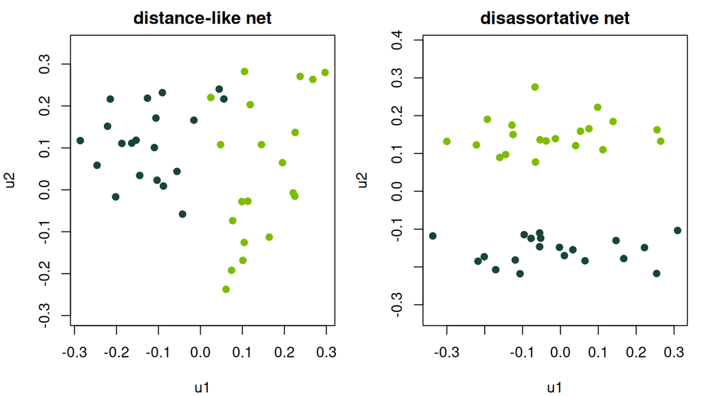

The factor model’s estimated positions (U) for the two test networks, colored by TRUE group. Left: the distance-generated network, with positive weights. Right: the disassortative network, with separation on the dimension carrying the large negative weight. The chosen two-dimensional distance fit missed the latter pattern. Orientation is arbitrary; fitted pairwise structure is not.

```r
par(mfrow = c(1, 2), mar = c(4, 4, 2, 1))
plot(eig_assort$U, col = ifelse(truth == 1, "#18453B", "#7BBD00"), pch = 19,
     xlab = "u1", ylab = "u2", main = "distance-like net", asp = 1)
plot(eig_dis$U, col = ifelse(truth == 1, "#18453B", "#7BBD00"), pch = 19,
     xlab = "u1", ylab = "u2", main = "disassortative net", asp = 1)
```

Now the full two-by-two. On the distance model’s home turf, the two models *tie*: 95% for the LDM, 95% for the factor model. Off it, the factor model recovers the true blocks at 100% where the distance model’s positions scored 55%. This is an illustration consistent with Hoff’s containment result: the factor fit retained the coarse group signal on the distance-generated example and represented the disassortative example much better at the same rank. K-means accuracy on two draws is not a proof, and it does not establish that one family will dominate on every dataset.

**ImportantThe one sentence for this section**

**In a symmetric eigenmodel, the sign of $\lambda_r$ describes one component of the fitted low-rank surface**: positive is assortative on that dimension; negative is disassortative. That flexibility is the eigenmodel’s advantage. When a network genuinely is assortative, the LDM’s restriction can be useful parsimony and its distance map is often easier to explain. When role mixing is plausible, compare it with an eigenmodel rather than assuming the geometry in advance. Prediction, posterior predictive checks, stability, and the research question should decide between them, not this one simulation.

# 8 Three fits, one object

Now the full model on real data. The trade network is *directed*, so first collect the one twist we owe the factor model: split each actor’s vector in two: a sending vector $u_i$ and a receiving vector $v_i$, and the multiplicative term generalizes to

$$\gamma(u_i, v_j) = u_i^\top v_j = \sum_{r=1}^{R} u_{i,r}v_{j,r}.$$

Any diagonal weights can be absorbed into $U$ or $V$, which is how `lame` stores the directed fit. The split lets an actor’s role as a *sender* differ from its role as a *receiver*, but it also ends the symmetric eigenvalue-sign story. There is no invariant directed analogue of “a negative $d_r$ means heterophily,” because signs and scales can move between the two factor matrices without changing their product.

Putting the additive and multiplicative pieces together on a latent scale $\theta_{ij}$ (with a link: identity for normal, probit for binary):

$$\theta_{ij} = \beta^\top x_{ij}
+ \underbrace{a_i + b_j}_{\substack{\text{additive}\\ \text{SRM, yesterday}}}
+ \underbrace{u_i^\top v_j}_{\substack{\text{multiplicative}\\ \text{directed low-rank surface}}},
\qquad
y_{ij} \mid \theta_{ij} \sim \text{family}.$$

That is **AME**: the additive and multiplicative effects model. The additive part is the SRM you already fit; the multiplicative part is a more flexible low-rank cousin of the distance model. Nothing from yesterday is thrown away; one term is added.

**CautionThe directed identification problem is larger than a rotation**

For any invertible $R\times R$ matrix $H$,

$$UV^\top=(UH)(VH^{-\top})^\top.$$

The likelihood sees the product, not a unique pair of factor matrices. An orthogonal rotation is only one possible $H$; rescaling and non-orthogonal mixing also leave the product unchanged. `lame` resolves this for display by taking an SVD-based canonical factorization of the posterior-mean multiplicative surface. That convention makes a plot reproducible, but it does not turn the raw axes, signs, or angles into model-invariant estimands. The safest directed quantities are the fitted surface $UV^\top$, its row and column profiles, and predictions built from it.

One word on `family`, because it is the only other lever: today you see `"normal"` (logged trade flows, below) and `"binary"` (the two eigen fits this morning). The *same call* fits `family = "poisson"` for counts and `"ordinal"` for ranks, and there are two censored likelihoods (`"cbin"`, `"frn"`, which need the `odmax` cap on out-degrees) built for survey-style “name up to $k$ partners” instruments. Swap the string, everything else about the day transfers unchanged.

With the full object named, the design that makes the synthesis visible: we fit three models on the exact same data, with covariates and additive effects, and watch what each one can and cannot reproduce:

1. **SRM**: additive only ($R = 0$). Yesterday’s model.
2. **LFM**: multiplicative only (additive effects off, $R = 2$). The latent factor term on its own.
3. **AME**: both. The synthesis.

## 8.1 The latent-model scorecard

These models are easiest to remember by the job each term performs. “can reproduce” is deliberate language here: matching a pattern is not the same as identifying the mechanism that generated it.

| Model | Explicit latent structure | Patterns it can reproduce compactly | Main limitation |
| --- | --- | --- | --- |
| SRM | Sender, receiver, and reciprocal dyad effects | Actor activity, popularity, and reciprocity | No low-rank or block-specific third-order structure |
| SBM | Discrete memberships and block-pair tie rates | Assortative, disassortative, core-periphery, and role patterns | A standard SBM has no free within-block activity effect |
| LDM | Positions with tie probability decreasing in distance | Smooth latent homophily and clustered triads | A small Euclidean space represents sharp role mixing inefficiently |
| LFM | A low-rank multiplicative surface | Assortative and role-based third-order patterns | No separate activity or reciprocity term; factors need an identification convention |
| AME | SRM plus the LFM surface | Actor heterogeneity, reciprocity, and broad low-rank higher-order structure | Reproduces structure without naming a closure mechanism or identifying a causal effect |

We use the same directed trade network you built yesterday: 30 countries, 870 directed dyads, so this is literally the object Day 2 handed forward.

```r
# (The file name keeps an older course numbering; this IS the Day 2 trade data.)
load("data/day9_srm.rda")
net <- netify(
  input   = trade, actor1 = "Var1", actor2 = "Var2",
  symmetric = FALSE, weight = "trade",
  nodal_vars = c("pop1", "gdp1", "polity1"),
  dyad_vars  = c("conflicts", "distance", "shared_igos"),
  dyad_vars_symmetric = c(FALSE, TRUE, TRUE)
)
ld <- to_lame(net)
# Named Ytr (trade), NOT Y; the morning's simulated network keeps the
# name Y, so you can re-run any earlier chunk after class without the two
# objects silently colliding.
Ytr <- ld$Y; Xd <- ld$Xdyad; Xr <- ld$Xrow; Xc <- ld$Xcol
c(actors = nrow(Ytr), dyads = nrow(Ytr) * (nrow(Ytr) - 1))
```

```
#> actors  dyads
#>     30    870
```

The only thing that changes across the three fits is which terms are switched on. That is the whole point: one family of models, three settings. (Each fit is seconds against the warm cache; cold, each takes ~30s.) And one shortcut for your own work: `ame(net, R = 2)` accepts the netify object directly: family and mode are inferred, no `to_lame()` unpack, but we unpack here so every piece the model eats is visible on the table.

**TipPlace your bet before the fits run**

The three models differ only in which dependence terms are switched on. Before a single one loads, predict: which of the three will reproduce the **triangles** in the trade network, and which will reproduce the **reciprocity**? Write it down: Section 9 is the answer, and the point is that *no single one of the three gets both* until the last row.

```r
# Additive only: R = 0. This is exactly Day 2's SRM.
trade_srm <- cache_fit("trade_srm", ame(
  Y = Ytr, Xdyad = Xd, Xrow = Xr, Xcol = Xc,
  family = "normal", symmetric = FALSE, R = 0, seed = 6886,
  nscan = 10000, burn = 10000, odens = 10, plot = FALSE, verbose = FALSE
))
```

```r
# Multiplicative only: R = 2, all additive/reciprocity terms OFF.
trade_lfm <- cache_fit("trade_lfm", ame(
  Y = Ytr, Xdyad = Xd, Xrow = Xr, Xcol = Xc,
  family = "normal", symmetric = FALSE,
  rvar = FALSE, cvar = FALSE, dcor = FALSE, R = 2, seed = 6886,
  nscan = 10000, burn = 10000, odens = 10, plot = FALSE, verbose = FALSE
))
```

```r
# The synthesis: additive effects AND a 2-dimensional multiplicative term.
trade_ame <- cache_fit("trade_ame", ame(
  Y = Ytr, Xdyad = Xd, Xrow = Xr, Xcol = Xc,
  family = "normal", symmetric = FALSE, R = 2, seed = 6886,
  nscan = 10000, burn = 10000, odens = 10, plot = FALSE, verbose = FALSE
))
```

Before we read anything, check that the sampler went somewhere. Same discipline as every MCMC day: trace plots first, then a number.

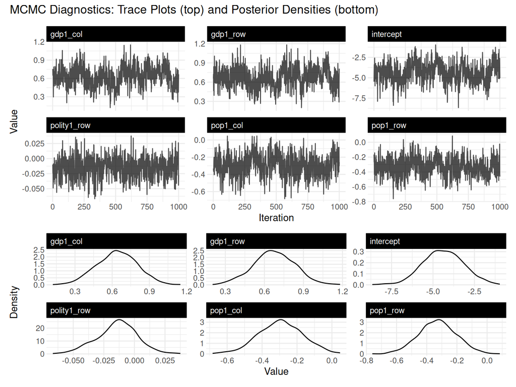

Trace plots for the AME regression coefficients. Fuzzy caterpillars centered on a stable level are what we want.

```r
trace_plot(trade_ame, include = colnames(trade_ame$BETA)[1:6])
```

```r
ess(trade_ame)   # Effective sample size per coefficient, out of 1000 draws
```

```
#>        intercept         pop1_row         gdp1_row      polity1_row
#>               82              201               95             1000
#>         pop1_col         gdp1_col      polity1_col   conflicts_dyad
#>              164               75             1000             1000
#>    distance_dyad shared_igos_dyad
#>              152               64
```

Read the printout honestly, against the ~**100** rule of thumb from Day 2. The worst mixer is shared igos, at 64; the handful of others sitting under the line (the intercept and the two gdp terms) are all the same story: gdp and IGO membership are nearly collinear because rich countries join more IGOs, so the sampler trades credit between them draw to draw, which drags ESS down without biasing either. Everything else clears the threshold, most of it by a mile. Usable, and if yours dropped further, the Day 2 fix applies: scan longer and thin harder (`nscan` up, `odens` up), not more burn-in. Do not take stability on faith either: exercise 3’s two-seed discipline works on `ame()` exactly as it does on `ergmm()`, and running it here is the honest way to check that the intervals hold.

## 8.2 The same readout, without course helpers

`ess()` above is a three-line convenience from this course’s `_setup.R`; fine in class, but not what you should type in your own project. The packaged path: `as_draws()` converts any `ame` fit into a draws object for the `posterior` package, and from there the entire modern MCMC-diagnostics stack applies to a network model exactly as it would to anything fit in stan:

```r
draws <- as_draws(trade_ame, include = c("beta", "vc"))  # Coefficients + variance components
dsum  <- posterior::summarise_draws(draws)
dsum[, c("variable", "mean", "sd", "rhat", "ess_bulk", "ess_tail")]
```

| variable | mean | sd | rhat | ess_bulk | ess_tail |
| --- | --- | --- | --- | --- | --- |
| intercept | -4.3847679 | 1.2179024 | 1.0027266 | 74.50435 | 323.8043 |
| pop1_row | -0.3284929 | 0.1244775 | 1.0052856 | 158.65175 | 617.2522 |
| gdp1_row | 0.6735949 | 0.1585136 | 1.0226407 | 72.18786 | 499.4645 |
| polity1_row | -0.0142574 | 0.0166021 | 0.9992583 | 864.79418 | 844.0532 |
| pop1_col | -0.2941238 | 0.1266138 | 1.0066321 | 111.07025 | 491.8371 |
| gdp1_col | 0.6376538 | 0.1622675 | 1.0211019 | 64.35452 | 377.9819 |
| polity1_col | -0.0056019 | 0.0168094 | 0.9990100 | 818.25764 | 946.5967 |
| conflicts_dyad | 0.0126978 | 0.0405012 | 0.9990382 | 850.87582 | 903.7774 |
| distance_dyad | -0.0344105 | 0.0050529 | 1.0342596 | 114.15090 | 221.3883 |
| shared_igos_dyad | -0.0371637 | 0.1295275 | 1.0822196 | 27.23705 | 114.8683 |
| va | 0.1937751 | 0.0598983 | 1.0078264 | 157.13372 | 685.6780 |
| cab | 0.1166093 | 0.0513588 | 1.0092311 | 163.91921 | 437.7354 |
| vb | 0.1929790 | 0.0600754 | 1.0001530 | 326.39903 | 659.0535 |
| rho | 0.6685355 | 0.0305355 | 0.9993788 | 878.69574 | 881.7711 |
| ve | 0.0683691 | 0.0045715 | 1.0079465 | 663.51795 | 929.2566 |

Same verdict as `ess()`: shared igos is the worst mixer, with `ess_bulk` of 27. It also adds a column `ess()` cannot give you: $\widehat R$. But read that $\widehat R$ honestly: computed on a single chain it is only the *split*-chain version, which asks whether the first half of the chain agrees with the second. The real question is whether *independent* chains started apart agree, and `ame()` will run them for you in parallel. Four chains cost roughly one chain’s wall time, about 50 seconds here, and the result ships cached:

```r
trade_ame4 <- cache_fit("trade_ame4", ame(
  Y = Ytr, Xdyad = Xd, Xrow = Xr, Xcol = Xc,
  family = "normal", symmetric = FALSE, R = 2, seed = 6886,
  nscan = 10000, burn = 10000, odens = 10,
  n_chains = 4, cores = 4, plot = FALSE, verbose = FALSE
))
rh <- posterior::summarise_draws(as_draws(trade_ame4, include = "beta"))
checkpoint(
  chains         = posterior::nchains(as_draws(trade_ame4, include = "beta")),
  worst_rhat     = max(rh$rhat),
  worst_ess_bulk = min(rh$ess_bulk)
)
```

```
#> ------------------------------------------------------------------
#> CHECKPOINT: chains = 4   |   worst_rhat = 1.015   |   worst_ess_bulk = 297.944
#> ------------------------------------------------------------------
```

Four chains, with a worst $\widehat R$ of 1.015, sit comfortably inside the classic 1.1 rule, a whisker over the strict 1.01 bar some journals now ask for (and once again it is the collinear gdp/igo block; the fix, if a referee insists, is just more `nscan`), and the pooled effective sample on the worst coefficient is now 298 rather than the single chain’s 64. That is the honest version of “converged,” and it is what I would report in a paper. (When a multi-chain fit finishes at the console it prints this same verdict as a banner; the single-chain cached fits stay the day’s workhorses because every number downstream was built on them.)

## 8.3 ALS Without the Math: Take Turns Until Nothing Changes

ALS stands for **alternating least squares**. It is not a new social science model. It is a fast way to find one point estimate for the same additive and multiplicative structure that AME can estimate with MCMC.

The basic idea is deliberately simple. Estimating every coefficient, actor effect, and latent factor at once is hard. Estimating one group while the others are temporarily fixed is much easier. ALS therefore takes turns:

1. Hold the current latent sender and receiver profiles fixed, then update the regression and additive actor effects.
2. Hold those updated pieces and the receiver profiles fixed, then update the sender profiles.
3. Hold the sender profiles fixed, then update the receiver profiles.
4. Repeat until another trip around the cycle barely improves the fit.

It is like adjusting rows and columns of a seating chart in alternating passes. Each pass solves an easier problem, and the passes together settle on a locally good arrangement. The word **locally** matters. With latent factors, the objective can contain several good-looking valleys, so different starting values can produce different answers. Multiple starts are part of the method, not an optional robustness flourish.

ALS is fast because it returns a point rather than exploring a posterior distribution. That makes it excellent for trying ranks, specifications, and large networks. It does not provide MCMC’s posterior draws, and one quick ALS solution should not be reported as if it represented full uncertainty. The useful division of labor is: **ALS to explore; MCMC to confirm and quantify uncertainty.**

### 8.3.1 Explore Fast, Confirm Slow: The ALS Estimator

Everything above is MCMC, and here MCMC is the route to posterior uncertainty. But thirty seconds per fit quietly shapes your workflow: you stop trying specifications. `lame` ships a second engine for exactly this: `ame(..., method = "als")`, which swaps the sampler for block coordinate descent (the same trick powering Day 7’s `sir` package) and returns a **point estimate only**: no chains, no intervals, seconds. The wrapper hides the tuning knobs, so call the engine directly when you need them: its default of 200 iterations stops early on this network, and `max_iter` is the fix:

```r
trade_als <- ame_als(
  Y = Ytr, Xdyad = Xd, Xrow = Xr, Xcol = Xc,
  family = "normal", symmetric = FALSE, R = 2,
  max_iter = 2000, seed = 6886, verbose = FALSE
)
c(converged = trade_als$converged, iterations = trade_als$iterations)
```

```
#>  converged iterations
#>          1        330
```

That ran in about two seconds. Put the two engines side by side on the same model:

```r
mcmc_beta <- apply(trade_ame$BETA, 2, mean)   # Posterior means, for comparison
round(cbind(
  als  = c(trade_als$mu, trade_als$beta[names(mcmc_beta)[-1]]),
  mcmc = mcmc_beta
), 2)
```

```
#>                    als  mcmc
#>                  -5.14 -4.38
#> pop1_row         -0.40 -0.33
#> gdp1_row          0.83  0.67
#> polity1_row      -0.02 -0.01
#> pop1_col         -0.37 -0.29
#> gdp1_col          0.80  0.64
#> polity1_col      -0.01 -0.01
#> conflicts_dyad    0.01  0.01
#> distance_dyad    -0.04 -0.03
#> shared_igos_dyad -0.17 -0.04
```

Same signs, same ordering, and the visible gaps sit exactly where you would predict: on the near-collinear gdp/igo block whose posteriors are widest. The ALS shared-igos value of -0.17 looks far from the MCMC -0.04, but the MCMC 95% interval runs (-0.29, 0.22), and both engines are telling you that coefficient is not pinned down. The rules of engagement, straight from the estimator’s documentation: for `family = "normal"` with $R = 0$ the ALS solution is exact; with $R > 0$ the objective is non-convex, so you get *a* local optimum (`multistart = "cheap"` or `"full"` guards against a bad one); and for binary or Poisson fits with $R > 0$ the point estimate carries a documented upward bias on the order of 10–15% (a Neyman–Scott effect: the factors are profiled, not integrated out). So the division of labor is: **ALS to explore specifications, ranks, and big networks; MCMC to confirm** the model you intend to defend. (`ame_als_bootstrap()` will wrap intervals around the ALS point, but it reproduces rather than removes that bias; it is not a substitute for the sampler.) You will see this engine earn its keep twenty fits at a time in Section 10’s dimension-selection callout.

# 9 Does it fit? The synthesis, demonstrated

Goodness of fit here means simulating networks from the fitted posterior and asking whether they look like the observed network on statistics we care about: actor heterogeneity, reciprocity (`dyad.dep`), and two flavors of triangle (`cycle.dep`, `trans.dep`). We put a number on it: how many posterior-predictive standard deviations is the observed value from the simulated ones? Small is good; anything past ~3 is a miss.

```r
gof_dist <- function(fit) {
  G <- fit$GOF; obs <- G[1, ]; sim <- G[-1, , drop = FALSE]
  round(sapply(colnames(G), function(s)
    unname(abs(obs[s] - mean(sim[, s])) / sd(sim[, s]))), 2)
}
gof_tab <- rbind(
  SRM = gof_dist(trade_srm),
  LFM = gof_dist(trade_lfm),
  AME = gof_dist(trade_ame)
)
gof_tab
```

```
#>     sd.rowmean sd.colmean dyad.dep cycle.dep trans.dep
#> SRM       0.30       0.28     1.02      9.34      9.71
#> LFM       0.04       0.04     7.41      1.10      1.22
#> AME       0.05       0.08     1.90      0.15      0.05
```

Read that table row by row; it is the whole latent-variable arc in one object.

- **The SRM (additive only) fails on triangles.** Its `trans.dep` is off by 9.71 standard deviations, reproducing the Day 2 cliffhanger exactly. Additive effects cannot build a triangle.
- **The LFM (multiplicative only) fixes the triangles but breaks reciprocity.** Its `dyad.dep` is off by 7.41. With no additive or reciprocity term, it has no way to know that trade is mutual. It solved Day 2’s leftover problem by re-opening a problem Day 2 had already solved.
- **The AME (both) fixes everything.** Transitivity down to 0.05, reciprocity to 1.9, and actor heterogeneity in hand. Every statistic within a couple of standard deviations.

**ImportantThis is why it is called additive *and* multiplicative**

Neither half is sufficient on its own, and they fix *different* things. The additive effects carry first- and second-order dependence (who is active, who reciprocates); the multiplicative term carries third-order dependence (who clusters with whom). The SRM row and the LFM row each have a big number in them; the AME row does not. That is the synthesis, and it is not a rhetorical claim; it is the 9.7 and the 7.4 collapsing to under 2.

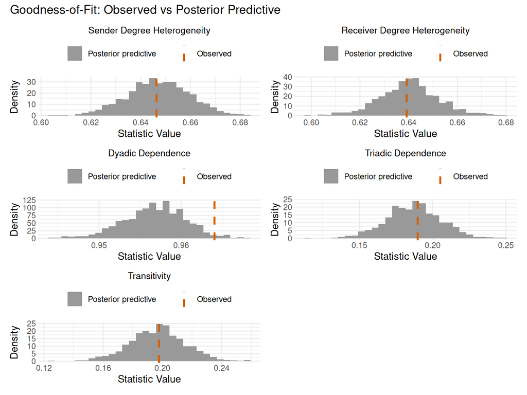

```r
gof_plot(trade_ame)
```

And when the argument hangs on two panels, as today’s does: `statistics=` subsets the display to exactly the ones you are arguing about:

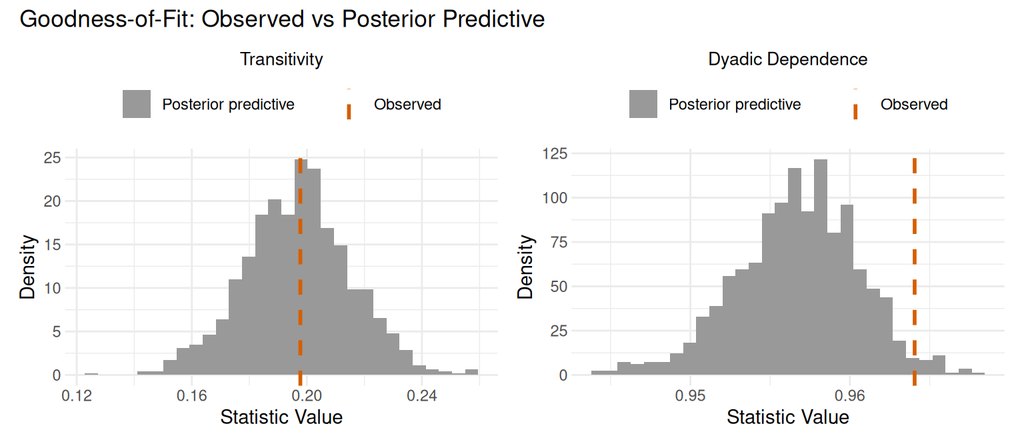

The same check, zoomed to the two statistics the whole day turns on: the triangles the SRM missed and the reciprocity the LFM broke.

```r
gof_plot(trade_ame, statistics = c("trans.dep", "dyad.dep"))
```

## 9.1 The fitted object also simulates and predicts

The `fit$GOF` table above is pre-computed at fit time, and it tracks five statistics. You are not limited to them: `simulate()` hands you whole networks from the posterior, and any statistic you can compute on a matrix becomes a GOF check. (This closes a loop from the morning: for the cameo we built posterior simulation *by hand* because latentnet’s undirected `simulate()` OR-couples the dyads. That was the lesson: verify the machinery, not a rule against ever calling `simulate()`; for directed `ame` fits the packaged method is the straightforward thing.) Try it on a statistic the built-in panel does not track: how concentrated the modeled log-trade outcome is in its ten largest entries:

```r
sims <- simulate(trade_ame, nsim = 50, seed = 6886)  # sims$Y: 50 posterior networks
top10_share <- function(M) {              # Fraction of summed log-trade values
  v <- sort(M[!is.na(M)], decreasing = TRUE)   # carried by the 10 largest entries
  sum(v[1:10]) / sum(v)
}
simv <- sapply(sims$Y, top10_share)
checkpoint(
  observed_top10_share = top10_share(Ytr),
  simulated_mean       = mean(simv),
  z_distance           = (top10_share(Ytr) - mean(simv)) / sd(simv)
)
```

```
#> ------------------------------------------------------------------
#> CHECKPOINT: observed_top10_share = 0.072   |   simulated_mean = 0.075   |   z_distance = -0.154
#> ------------------------------------------------------------------
```

The observed concentration sits 0.15 posterior-predictive standard deviations from the simulated mean, and the model reproduces a distributional feature it was never asked to match. That is the strong form of the GOF discipline: invent the statistic *your* theory cares about and check it yourself.

The last verb the fitted object knows is `predict()`: “what does the model expect this tie to be?”, which returns the posterior expected value of every dyad as an $n \times n$ matrix:

```r
EY <- predict(trade_ame, type = "response")
round(cbind(predicted = EY["UKG", c("ITA", "BNG", "EGY")],
            observed  = Ytr["UKG", c("ITA", "BNG", "EGY")]), 2)
```

```
#>     predicted observed
#> ITA      2.77     2.55
#> BNG      0.21     0.17
#> EGY      0.09     0.00
```

In-sample the fit is extremely tight: the correlation between predicted and observed across all 870 dyads is 0.97, but treat that number as flattery, not evidence: the model has seen every one of these dyads. The honest version of this check hides dyads first and predicts them cold, which is exactly what the dimension-selection callout in Section 10 now does.

# 10 Reading the latent space

The multiplicative term is not just a fit-improving device; it is estimated structure you can look at. The sender vectors live in `trade_ame$U` and the receiver vectors in `trade_ame$V`.

**Warning`UVPM` vs `tcrossprod(U, V)`: the surface and its rank-R display**

`trade_ame$UVPM` is the posterior mean of the multiplicative surface, $E[UV^\top\mid Y]$. It is the primary model quantity. In `lame` 1.3.2, the reported `trade_ame$U` and `trade_ame$V` come from an SVD-based rank-$R$ factorization of that posterior-mean surface. They are not separate posterior means whose product invokes the “mean of a product” problem.

`tcrossprod(trade_ame$U, trade_ame$V)` is therefore the rank-$R$ reconstruction of `UVPM`. It can differ slightly because a posterior mean of rank-$R$ draws need not itself have rank exactly $R$.

```r
UV_rankR <- tcrossprod(trade_ame$U, trade_ame$V)
c(sd_surface = round(sd(c(trade_ame$UVPM)), 3),
  rankR_reconstruction_rmse = round(
    sqrt(mean((UV_rankR - trade_ame$UVPM)^2)), 4))
```

```
#>                sd_surface rankR_reconstruction_rmse
#>                    0.4190                    0.0188
```

The surface standard deviation is a useful first diagnostic: if it is nearly zero, there is little posterior-mean multiplicative structure to interpret, no matter how pretty a factor plot looks. If saved posterior draws disagree in orientation or sign, averaging can also cancel structure, so a publication fit should pair this check with draw-level stability rather than treating one number as a test.

The standard visualization is a **circle plot**: project the factors onto two dimensions and place each actor on the circle, sized by how strongly the multiplicative term moves its ties. Actors that sit near each other play similar structural roles.

`ggCirc()` takes the sociomatrix `Y` and the two factor matrices `U` and `V`; everything else is cosmetic. The color vector is repeated (`rep(ccols, 2)`) because the plot draws one point per actor as a **sender** and again as a **receiver**, so it needs the region color twice, once for each copy. To reuse this on your own data you really only need `ggCirc(Y, U, V)`; the theming below just strips axes and the legend.

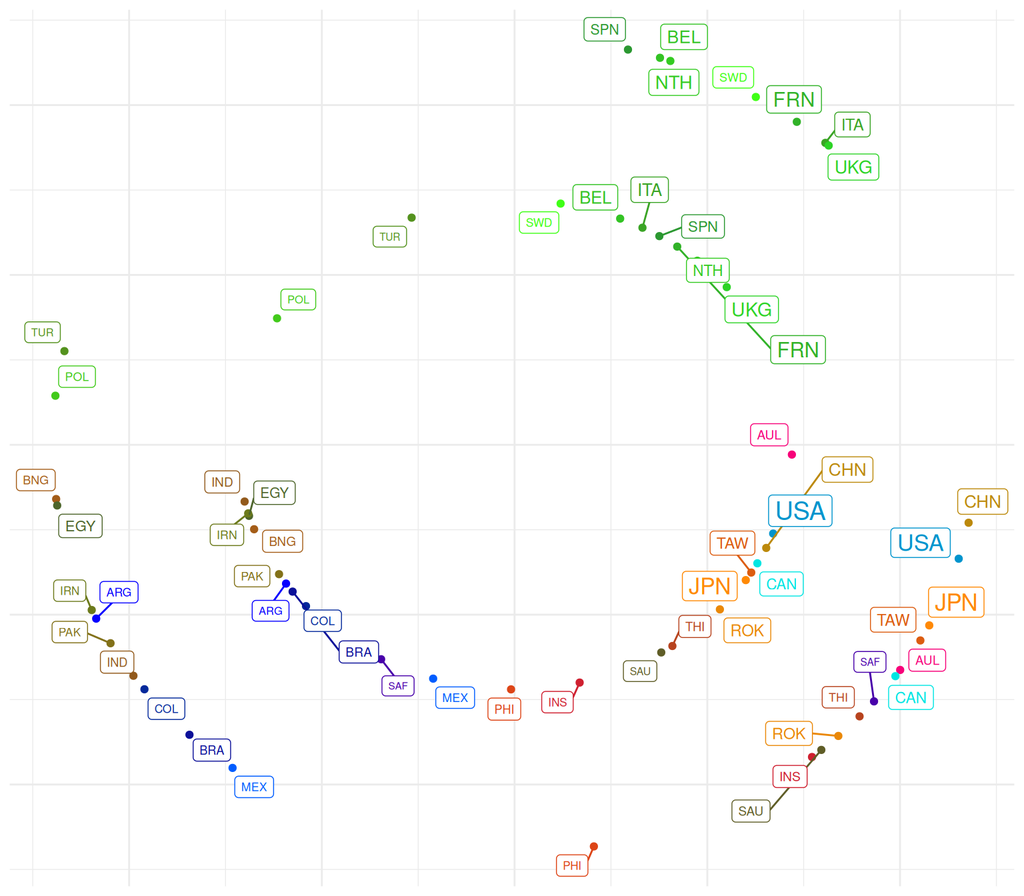

The estimated multiplicative structure of the trade network. Actors near each other occupy similar roles; color is region. This is the trade network’s latent geometry after conditioning on gdp, population, polity, distance, conflict and igos.

```r
load("data/tradeMapCols.rda")
yMat <- acast(trade, Var1 ~ Var2, value.var = "trade")
ggCirc(Y = yMat, U = trade_ame$U, V = trade_ame$V,
       color = names(rep(ccols, 2))) +
  scale_color_manual(values = rep(ccols, 2)) +
  theme_minimal() +
  theme(legend.position = "none",
        axis.text = element_blank(), axis.title = element_blank())
```

One honesty note about that figure: `ggCirc()` is a bespoke helper sourced from this day’s `ameHelpers.R`; it does **not** ship with `lame`, so on your own machine, on your own data, you would have to copy that file around forever. The portable equivalent is packaged, and it is one line:

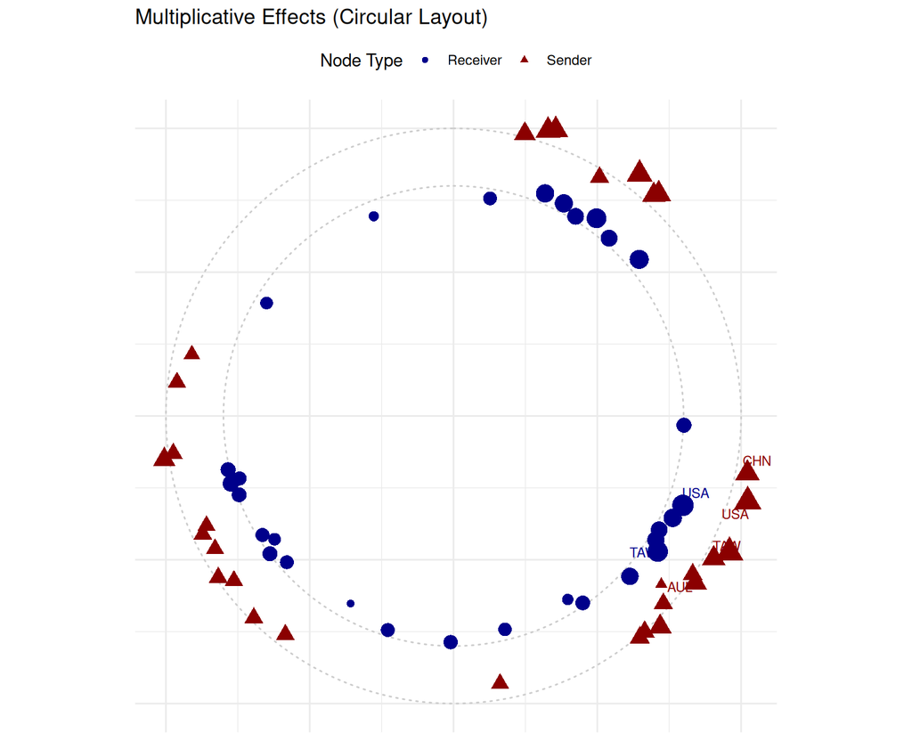

The packaged version of the same figure: uv_plot(). Senders as triangles, receivers as circles, sized by how strongly the multiplicative term moves their ties; only the strongest actors are labeled by default. Layout = ‘biplot’ is the other built-in view.

```r
uv_plot(trade_ame, layout = "circle")
```

Same geometry, zero copied helper files. Use `ggCirc()` when you want the publication-styled version of this course’s figures, `uv_plot()` everywhere else. When you want the *coordinates* rather than a picture, whether to merge with covariates or to hand to a clustering routine the way we did all morning, `latent_positions()` returns them in a tidy format:

```r
head(latent_positions(trade_ame))
```

| actor | dimension | time | value | posterior_sd | type |
| --- | --- | --- | --- | --- | --- |
| ARG | 1 | 1 | -0.3460079 | NA | U |
| AUL | 1 | 1 | 0.4077265 | NA | U |
| BEL | 1 | 1 | 0.3312069 | NA | U |
| BNG | 1 | 1 | -0.4126384 | NA | U |
| BRA | 1 | 1 | -0.3055302 | NA | U |
| CAN | 1 | 1 | 0.6767305 | NA | U |

(The `posterior_sd` column is `NA` because the cached fits store only the canonical point summaries of $U$ and $V$; refit with `posterior_opts = posterior_options(save_UV = TRUE)` and it fills in, which is also what unlocks `simulate_posterior()` in the toolbox callout below.)

**NoteUsing a latent quantity in your next analysis**

Sometimes the latent relation is the product you want to carry into a second model: strategic affinity into an aid regression, for example. Do not treat a posterior-mean coordinate as if a survey measured it without error.

1. Choose an identified quantity. For a directed AME fit, the multiplicative surface, predicted tie propensities, and distances between fitted row or column profiles survive factor reparameterization. Raw axis labels do not.
2. Propagate uncertainty. Save factor draws, compute the invariant quantity on each draw, run the downstream calculation on each draw, and summarize the resulting distribution. A joint model or a bootstrap can serve the same purpose. One regression on a posterior mean understates first-stage uncertainty.
3. Align only when coordinates themselves are substantively necessary. Distance-model draws need Procrustes alignment; directed factor draws need the package’s canonicalization or a method designed for the full bilinear invariance.
4. Validate labels externally. Calling an axis “ideology” because familiar countries sit at its ends is a hypothesis, not something the likelihood named for you.
5. Remember that uncertainty propagation does not create causal identification. If the same unmeasured process drives the network-derived quantity and the downstream outcome, the second model still has a confounding problem.

To turn the fitted surface into something you can rank, compare actors’ **sender profiles**: row $i$ of `UVPM` records how the multiplicative term moves actor $i$’s ties to every receiver. Cosine distance between these rows asks whether two senders lean toward the same receivers. Unlike cosine distance between raw rows of $U$, this profile comparison is unchanged by $U\mapsto UH,\ V\mapsto VH^{-\top}$ because it starts from the invariant product.

```r
cos_dist <- function(x, y) 1 - sum(x * y) / (sqrt(sum(x^2)) * sqrt(sum(y^2)))
# Dprofile, not D; the morning's simulated distance matrix keeps the name D
sender_profile <- trade_ame$UVPM
n <- nrow(sender_profile)
Dprofile <- matrix(NA, n, n,
                   dimnames = list(rownames(sender_profile),
                                   rownames(sender_profile)))
for (i in 1:n) for (j in 1:n)
  Dprofile[i, j] <- cos_dist(sender_profile[i, ], sender_profile[j, ])
round(Dprofile[1:4, 1:4], 2)
```

```
#>      ARG  AUL  BEL  BNG
#> ARG 0.00 1.63 1.68 0.03
#> AUL 1.63 0.00 1.12 1.80
#> BEL 1.68 1.12 0.00 1.46
#> BNG 0.03 1.80 1.46 0.00
```

Those are just the first four actors: the point of the matrix is to *rank*, so pull the six closest pairs out of the whole thing, on screen where you can check them.

```r
Doff <- Dprofile; Doff[lower.tri(Doff, diag = TRUE)] <- NA  # Each pair once
# c() first: statnet.common masks order() with a method that mishandles
# matrices, so hand it a plain vector.
ord  <- base::order(c(Doff), na.last = NA)[1:6]
top_pairs <- arrayInd(ord, dim(Doff))
data.frame(pair   = paste(rownames(Dprofile)[top_pairs[, 1]],
                          rownames(Dprofile)[top_pairs[, 2]], sep = "-"),
           profile_cosine = signif(Doff[ord], 2))
```

| pair | profile_cosine |
| --- | --- |
| ITA-UKG | 8.7e-05 |
| ARG-IRN | 3.8e-04 |
| BEL-NTH | 3.9e-04 |
| INS-SAU | 4.1e-04 |
| AUL-CAN | 7.2e-04 |
| BNG-EGY | 8.0e-04 |

The nearest pair in the fitted sender profiles is **the UK and Italy**: their cosine distance is essentially zero, so the model has learned that the multiplicative term pushes their ties toward the same kinds of partners. As it happens they also trade heavily with each other (2.55 and 2.6 against sender row means of 1.3 and 1.2), so here a shared fitted role and a direct tie happen to coincide. That is descriptive, not evidence that a particular homophily mechanism caused the tie.

```r
# Two close fitted sender profiles, with their direct trade flows
round(rbind(
  UKG_ITA = c(profile_cosine = Dprofile["UKG", "ITA"],
              trade_ij = yMat["UKG", "ITA"], trade_ji = yMat["ITA", "UKG"]),
  BNG_EGY = c(profile_cosine = Dprofile["BNG", "EGY"],
              trade_ij = yMat["BNG", "EGY"], trade_ji = yMat["EGY", "BNG"])
), 3)
```

```
#>         profile_cosine trade_ij trade_ji
#> UKG_ITA          0.000    2.549    2.603
#> BNG_EGY          0.001    0.000    0.000
```

Among the six closest fitted sender profiles is **Bangladesh and Egypt**: profile distance 0.0008, with **zero trade between them in either direction**. That is a clean illustration of stochastic equivalence: the fitted multiplicative surface says they lean toward the same kinds of partners without requiring them to touch each other. A simple low-dimensional distance map ties role similarity to direct proximity, so this pattern is awkward there. The factor surface separates the two ideas.

**CautionCarry the identification habit, not the exact Procrustes rule**

The morning’s habit applies: do not interpret a coordinate until you know which transformations leave the fitted model unchanged. The exact rule does not transfer verbatim. A distance map is invariant to translation and orthogonal transformations, which ordinary Procrustes removes. A directed factorization is invariant to the larger transformation $U\mapsto UH,\ V\mapsto VH^{-\top}$ for any invertible $H$.

So raw coordinates, column signs, and angles between rows of $U$ are not safe model quantities on their own. `lame`’s SVD convention gives them a stable display, and a package alignment routine is useful when comparing stored draws or time points under that convention. The fitted `UVPM` surface, profile comparisons computed from it, and predictions are invariant without needing that interpretive leap.

**NoteHow many dimensions? The R question, with local optima taken seriously**

We chose $R = 2$. There is no formula; you select $R$ the way you select any complexity parameter, by asking what it buys and whether the answer is stable. Three checks belong together: **(1)** does the posterior-mean multiplicative surface carry nontrivial variation? **(2)** does it improve held-out prediction? **(3)** does that conclusion survive different folds and local starts? Gof alone is not enough because in-sample fit usually rewards extra rank.

The ALS objective is non-convex for $R>0$. A spectacular held-out error from one start can be rank overfit, a bad local optimum, numerical extrapolation, or all three. The loop below therefore repeats the fold assignment and uses `multistart = "cheap"` within every fit. It reports the distribution across folds rather than hiding it behind one mean. `which()` matters because the diagonal of `fold_id` is `NA`, and `lowrank_method = "hybrid"` is the documented choice when outcomes are held out.

```r
cv_fold <- cache_fit("cv_rmse_multistart", {
  folds <- 5
  repeats <- 2
  ranks <- 0:3

  do.call(rbind, lapply(seq_len(repeats), function(rep_id) {
    set.seed(6885 + rep_id)
    fold_id <- matrix(sample(1:folds, length(Ytr), replace = TRUE), nrow(Ytr))
    diag(fold_id) <- NA

    do.call(rbind, lapply(ranks, function(k_dim) {
      fold_rmse <- sapply(seq_len(folds), function(f) {
        hold <- which(fold_id == f)
        Ymiss <- Ytr
        Ymiss[hold] <- NA
        fit <- ame_als(
          Ymiss, Xd, Xr, Xc,
          family = "normal", symmetric = FALSE, R = k_dim,
          max_iter = 2000, lowrank_method = "hybrid",
          multistart = "cheap",
          seed = 6886 + 100 * rep_id + 10 * k_dim + f,
          verbose = FALSE
        )
        sqrt(mean((fitted(fit)[hold] - Ytr[hold])^2))
      })
      data.frame(rep_id = rep_id, R = k_dim,
                 fold = seq_len(folds), rmse = fold_rmse)
    }))
  }))
})

cv_summary <- do.call(rbind, lapply(split(cv_fold$rmse, cv_fold$R), function(x)
  c(mean = mean(x), median = median(x), sd = sd(x),
    min = min(x), max = max(x))))
round(cv_summary, 3)
```

```
#>    mean median    sd   min    max
#> 0 0.442  0.434 0.052 0.376  0.550
#> 1 0.389  0.377 0.050 0.314  0.473
#> 2 0.343  0.315 0.076 0.259  0.492
#> 3 2.354  0.993 3.111 0.328 10.478
```

Read the whole row, not just the winner. Average held-out RMSE improves from 0.44 at $R=0$ to 0.34 at $R=2$, and the $R=2$ result is much more stable than the earlier single-start comparison suggested. $R=3$ is the warning row: some folds fit well, while others extrapolate badly enough to push its range from 0.33 to 10.48. That instability says **do not trust $R=3$ here**. It does not prove that the data’s true rank is two, and it does not let us distinguish weak support from optimizer trouble using this table alone. The defensible conclusion is narrower: $R=2$ earns predictive rent in this exercise; $R=3$ does not earn a stable one. Confirm a publication choice with stronger starts, repeated partitions, and the MCMC fit you intend to report.

One packaging pointer before you leave this box: the loop above hand-rolls its own scoring so every moving part is on the table, but the grader is also packaged: `evaluate_heldout(y_obs, y_pred, mask, family)` takes the observed matrix, `fitted()` from a fit trained with the held-out cells set to `NA`, and the logical mask of cells to score, and returns family-appropriate scores (rmse, mae, and mean log density for a normal fit like this one; auroc, pr-auc, and brier for binary fits).

**NoteThe full toolbox: the rest of the fitted object (self-study)**

The day used the parts of an `ame` fit that carry the argument. The rest of the everyday surface takes one line each, and all of it runs against the cached fit:

```r
# The paper table in one line: posterior means, sds, credible intervals
tidy(trade_ame, conf.int = TRUE)
```

| term | estimate | std.error | statistic | p.value | conf.low | conf.high |
| --- | --- | --- | --- | --- | --- | --- |
| intercept | -4.3847679 | 1.2179024 | -3.6002621 | 0.0003179 | -6.7089087 | -1.9861975 |
| pop1_row | -0.3284929 | 0.1244775 | -2.6389737 | 0.0083157 | -0.5757116 | -0.0810277 |
| gdp1_row | 0.6735949 | 0.1585136 | 4.2494445 | 0.0000214 | 0.3637223 | 0.9851212 |
| polity1_row | -0.0142574 | 0.0166021 | -0.8587703 | 0.3904672 | -0.0490101 | 0.0166735 |
| pop1_col | -0.2941238 | 0.1266138 | -2.3229991 | 0.0201792 | -0.5452144 | -0.0479904 |
| gdp1_col | 0.6376538 | 0.1622675 | 3.9296468 | 0.0000851 | 0.3223206 | 0.9469789 |
| polity1_col | -0.0056019 | 0.0168094 | -0.3332579 | 0.7389396 | -0.0389943 | 0.0257660 |
| conflicts_dyad | 0.0126978 | 0.0405012 | 0.3135162 | 0.7538885 | -0.0658607 | 0.0942815 |
| distance_dyad | -0.0344105 | 0.0050529 | -6.8099858 | 0.0000000 | -0.0441875 | -0.0243623 |
| shared_igos_dyad | -0.0371637 | 0.1295275 | -0.2869173 | 0.7741756 | -0.2885299 | 0.2224041 |

```r
# The one-row fit summary: family, mode, R, actors, stored draws
glance(trade_ame)
```

| nobs | n_actors | n_row_actors | n_col_actors | n_periods | n_stored | family | mode | R | dynamic_uv | dynamic_ab | dynamic_beta | elpd_loo |
| --- | --- | --- | --- | --- | --- | --- | --- | --- | --- | --- | --- | --- |
| 870 | 30 | NA | NA | 1 | 1000 | normal | unipartite | 2 | FALSE | FALSE | FALSE | NA |

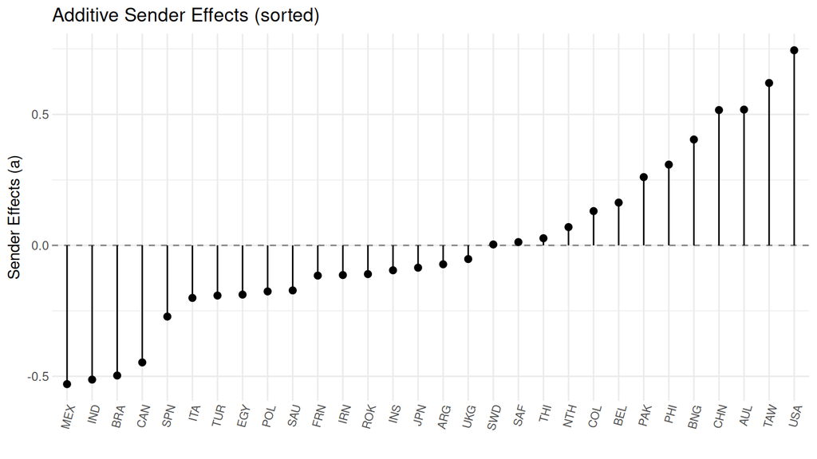

Ab_plot(): yesterday’s additive sender effects, pulled off today’s fit in one line: the SRM half of AME is still in there, estimated and inspectable.

```r
# Day 2's additive-effects caterpillar, packaged
ab_plot(trade_ame, effect = "sender")
```

```r
# The full linear predictor E[Z] = Xbeta + a + b' + UV', reconstructed
# on demand (deliberately not stored on the fit object, to keep it small):
round(reconstruct_EZ(trade_ame)[1:3, 1:3], 2)
```

```
#>      ARG  AUL  BEL
#> ARG 0.93 0.92 0.25
#> AUL 1.08 2.73 1.11
#> BEL 0.33 1.34 2.43
```

Three more that need one sentence each rather than a demo:

- `simulate_posterior(trade_ame, component = "UV")` draws whole factor configurations from the posterior, but only from fits run with `posterior_opts = posterior_options(save_UV = TRUE)`; the cached fits here were not, and it will tell you so in plain language.
- `lame::procrustes_align()` is the packaged function that our morning function masks. It aligns factor positions across time points in longitudinal fits, automating the Procrustes discipline.
- `coef()`, `vcov()`, `confint()`, `fitted()`, `residuals()` all behave the way they do on `lm()`; an `ame` fit is a citizen of the standard R modeling world.

# 11 What today did *not* buy you

Here is the slide that took me too long to put in the deck. Everything above is the sales pitch for the latent-variable program: better calibration under the assumed model, better fit, useful predictions, and substantive structure you can interpret with care. But there is a hard boundary, and you should leave today knowing exactly where it is.

The main simulation in *Taking Dyads Seriously* (Minhas et al. 2022) gives the latent model a data-generating process it can represent. When the unmeasured structure $W$ is independent of the observed covariate $X$, AME recovers $\beta$ and calibrates its intervals much better than the independence model. When $W$ and $X$ are correlated, the same guarantee disappears:

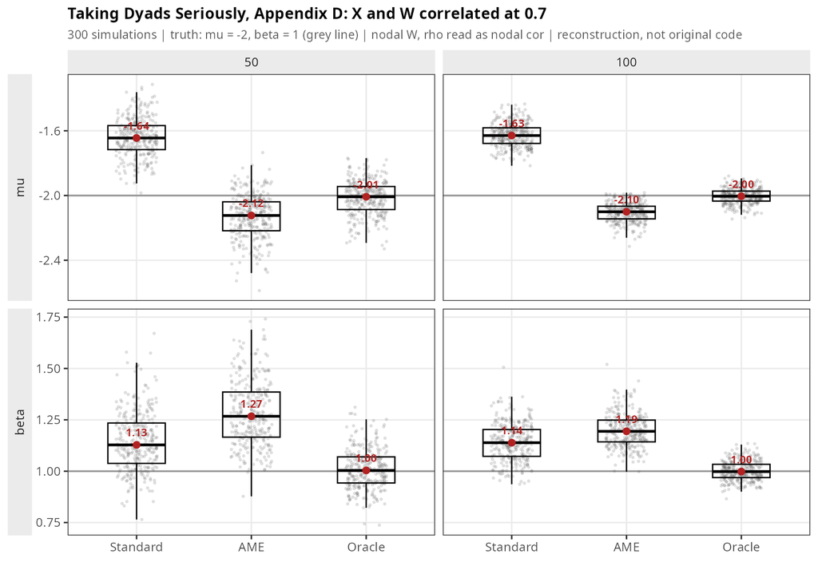

Reconstruction of Appendix D of Minhas et al. (2022). Truth is the grey line ($\mu=-2$, $\beta=1$). When the unobserved homophily term W is correlated with X (here at 0.7), the AME estimate of $\beta$ drifts off the truth just like the standard model; only the oracle, which actually observes W, recovers it.

**ImportantAbsorbing dependence is not the same operation as controlling a confounder**

The simulation’s useful intuition is that AME can represent residual low-rank structure that remains after the measured covariates. The observed network alone cannot tell the model how to divide structure shared by $W$ and $X$ into a “covariate part” and a “latent part.” Adding rank therefore does not mechanically remove confounding. Today’s machinery buys a model for dependence, fit, prediction, and structure. **It does not buy causal identification.**

## 11.1 What $\beta$ means in each model

Across this week, $\beta$ lives in a **conditional linear predictor**. The thing held fixed changes by model, so the honest sentence changes too.

| Model | What the coefficient conditions on | The honest reading |
| --- | --- | --- |
| SRM | Sender and receiver effects, plus reciprocity in the observation model | Association with the outcome on the link scale among dyads with the same modeled actor propensities |
| SBM | The relevant block-pair baseline, or the mixed-membership average over block pairs | Block-adjusted association, provided the covariate still varies within the block-pair comparisons doing the estimation |
| LDM | Latent distance and any activity terms included in the specification | Association at a fixed fitted distance, not a pure institutional or treatment effect |
| AME | Additive effects and the fitted multiplicative surface | Association at a fixed modeled sender, receiver, and low-rank relational profile |

Two translations keep that table from becoming a slogan. First, a probit or logit coefficient is not a percentage-point change. For a binary covariate, the conditional probability contrast for one dyad is

$$g^{-1}(\eta_{ij}+\beta)-g^{-1}(\eta_{ij}),$$

Which depends on the dyad’s baseline $\eta_{ij}$. A population-averaged contrast additionally integrates over the distribution of actor and latent effects, so it is generally not equal to $\beta$. With a Gaussian identity link, conditional and marginal slopes can coincide under the model’s mean-independence assumptions; with nonlinear links they generally do not.

Second, every conditional comparison needs support. If alliance status is nearly determined by block membership, for example, there may be almost no allied-versus-unallied variation within the relevant block pairs. No amount of latent adjustment creates that missing comparison. And if changing $X$ would itself change the latent positions, “hold the positions fixed” describes the fitted conditional association, not the total effect of an intervention.

**NoteExogeneity is an assumption, not a diagnostic from the same fit**

Three different ideas are easy to blur:

1. **A random-effects assumption.** A standard latent model specifies a distribution for the latent effects, often independent of $X$ or with zero conditional mean. One can instead model how latent effects depend on $X$, but that relationship must come from an explicit model or additional information. The likelihood cannot discover the right exogeneity story by vocabulary alone.
2. **An omitted-variable calculation.** In a simple linear regression, the familiar bias expression uses the covariance between a residualized regressor and an omitted term. It is a useful intuition, not an exact formula for probit AME, an SBM with estimated memberships, or an LDM with jointly estimated positions.
3. **A causal identification assumption.** Causal language additionally needs a defensible treatment assignment story, consistency, overlap, and an interference assumption that matches the network. Random-effects exogeneity is not a substitute for those requirements.

The tempting diagnostics do less than their names suggest. A path of $\hat\beta$ across $R$ or $K$ is a **sensitivity analysis**, not a test that the final coefficient is exogenous. A stable path can be stably biased. A moving path does not decompose the estimate into “selection” and “treatment.” Posterior predictive checks and cross-validation test reproduction and prediction, not causal exchangeability. Regressing estimated factors on $X$ can describe what the fitted model absorbed, but it does not test whether the unobserved true factor was independent of $X$.

Panel language raises the bar again. **Strict exogeneity** conditions current errors on past, present, and future covariates; **sequential exogeneity** uses the information available up to the current period. Lagging $X$ does not by itself establish either one, especially when ties and attributes feed back on each other.

The practical response is not despair. Measure important pre-treatment confounders, use actor fixed effects or correlated random-effects strategies where the required within-actor variation exists, defend a design when you have one, and report sensitivity across substantively plausible structures. Remember that actor fixed effects cannot separately estimate a time-invariant actor covariate, and that dyadic cluster-robust standard errors repair an uncertainty calculation under their assumptions, not omitted-variable bias.

And that sentence opens a door this course walks through on **Day 6**, which is a full session on the second, completely different family of answers to dyadic dependence: leave the model alone and fix the *standard errors* (dyadic cluster-robust SEs), and, harder and more interesting, ask what it would even mean to make a *causal* claim about a network, where one unit’s treatment can touch another unit’s outcome. There is a published census of how badly naive dyadic standard errors mislead, there is an honest unresolved argument between that literature and the modeling tradition you learned today (I have a foot in both camps, and Day 6 stages the disagreement on real data), and there is a discipline for saying “we cannot defend the assumptions” without pretending no method exists. None of that fits in this section; all of it is Day 6.

For today, the takeaway is narrower and it is enough: read every AME (or SRM, or LDM, or blockmodel) coefficient as a *dependence-adjusted association*, not a causal effect. Its intervals and structural summaries are model-based and inherit the model’s assumptions. They are not an identification strategy.

## 11.2 After the Model Runs: Interpret the Relational Surface, Not the Axes

A latent model gives you at least two kinds of results, and they should not be collapsed into one sentence. First, it estimates observed covariate associations conditional on the fitted latent structure. Second, it estimates a relational surface that summarizes patterned residual affinity. The political interpretation should address both.

1. **Start with the observed association.** Explain how its sign, magnitude, and uncertainty change after additive or latent structure enters the model. Call it dependence-adjusted unless a separate design supports causal language.
2. **Interpret invariant relational quantities.** Discuss fitted tie probabilities, distances, inner products, clusters, or pairs of actors that the model places close together. Raw coordinate axes, rotations, reflections, and separate AME factor columns are not uniquely identified political dimensions.
3. **Ask what the latent term may contain.** Strategic alignment, omitted institutions, geography, measurement error, and common exposure can all contribute. The model does not label that mixture for you.
4. **Report whether the model earns the interpretation.** Use posterior predictive checks, held-out prediction when appropriate, sensitivity to rank or dimension, alignment diagnostics, and uncertainty in positions or factors.

**TipA human version of the result**

“States with similar fitted strategic profiles are more likely to ally after accounting for the observed covariates in the model. Adding the latent surface also improves reproduction of the degree and triadic patterns that the covariates alone miss. We do not interpret either map axis as ideology because the orientation is unidentified, and we treat the covariate coefficient as a dependence-adjusted association rather than a causal effect.”

If the closest or most compatible actor pairs make political sense, explain why. If they do not, treat that as evidence about model fit or omitted structure rather than forcing a story onto the map. A useful latent-model result connects a stable relational pattern to a political puzzle while remaining honest about what the geometry cannot name.

# 12 Your turn

**TipExercises**

**Required.**

**1.** Pull the estimated positions out of the alliance cameo fit (`ls2d$mkl$Z`) and find the two states that sit *closest* together in the latent space, and the two that sit *farthest apart*. Do the close pair share an alliance? Report the pair and one sentence on whether it makes sense.

**2.** The synthesis claim rests on one table. Reproduce it in your own words: using `gof_dist()`, report the single worst statistic for `trade_srm`, for `trade_lfm`, and for `trade_ame`, and write one sentence naming *what kind of dependence* each model is failing (or, for AME, not failing) to reproduce.

**Stretch.**

**3.** The identifiability point, for real this time. Fit the 2-D alliance model a second time with a different seed, pull both sets of positions, and (a) plot them raw: confirm they look different; (b) align the second to the first with `procrustes_align()` from Section 5 and plot again. Write one sentence distinguishing the arbitrary pose Procrustes removed (translation, rotation, and reflection) from any part it *could not* remove (posterior uncertainty, Monte Carlo error, weak identification, or a different local mode).

**4 (your own data).** Take any network of your own (binary or weighted). Fit `ame(..., R = 2)` with `symmetric =` whatever your network is. Then: (a) check `sd(c(fit$UVPM))` (directed) or `sd(c(fit$ULUPM))` (symmetric). Is there multiplicative structure worth reading at all? (b) If symmetric, read the signs of `diag(fit$L)`: is your network’s latent structure assortative, disassortative, or mixed? Connect the sign to something you know substantively about the network.

**Solutions: open after you have tried them**

```r
## 1. Closest and farthest pairs ------------------------------------
Zsol <- ls2d$mkl$Z
rownames(Zsol) <- network.vertex.names(AllyNet)
Dsol <- as.matrix(dist(Zsol))
Dsol[lower.tri(Dsol, diag = TRUE)] <- NA
closepair <- which(Dsol == min(Dsol, na.rm = TRUE), arr.ind = TRUE)
farpair   <- which(Dsol == max(Dsol, na.rm = TRUE), arr.ind = TRUE)
rownames(Zsol)[c(closepair)]   # The closest pair
rownames(Zsol)[c(farpair)]     # The farthest pair
# The closest pair should be two states that are in fact allied and
# geographically/politically similar; the model put them together
# BECAUSE they tie. Closeness is a compression of the whole tie profile.

## 2. Worst statistic per fit ---------------------------------------
worst <- function(fit) { g <- gof_dist(fit); g[which.max(g)] }
sapply(list(SRM = trade_srm, LFM = trade_lfm, AME = trade_ame), worst)
# SRM's worst is trans.dep (~9.7): it cannot build triangles.
# LFM's worst is dyad.dep  (~7.4): it has no reciprocity term.
# AME's worst is ~2:        it fails nothing meaningfully.

## 3. Two seeds + procrustes ----------------------------------------
ls2d_b <- cache_fit("ls2d_seed2", ergmm(
  AllyNet ~ euclidean(d = 2),
  control = ergmm.control(sample.size = 4000, interval = 10,
                          burnin = 10000),
  seed = 12345, verbose = FALSE))
Za <- ls2d$mkl$Z; Zb <- ls2d_b$mkl$Z
par(mfrow = c(1, 2))
plot(Za, pch = 19, main = "seed 6886"); plot(Zb, pch = 19, main = "seed 12345")
al <- procrustes_align(Zb, Za)
plot(scale(Za, scale = FALSE), pch = 19, col = "blue")
points(al$aligned, pch = 1, col = "red")   # Aligned second fit over the first
# Rotation/reflection is removed by procrustes. What remains can reflect
# posterior uncertainty, monte carlo error, weak identification, or different
# local modes. It is a stability warning, not a diagnosis of MC noise alone.

## 4. Your own network ----------------------------------------------
# fit <- ame(Y = <your matrix, diag NA>, family = "binary",  # Or "normal"...
#            symmetric = TRUE, R = 2, seed = 6886,
#            nscan = 4000, burn = 2000, odens = 10,
#            plot = FALSE, verbose = FALSE, print = FALSE)
# sd(c(fit$ULUPM))     # Symmetric; directed: sd(c(fit$UVPM))
# diag(fit$L)          # Symmetric only: the eigenvalue-sign readout
# Positive lambda -> assortative/distance-like communities;
# Negative lambda -> role structure / disassortative mixing (a distance
# model may need much more dimension to represent this compactly); mixed
# signs -> both at once, which is common in real networks and is a central
# reason to consider the eigenmodel alongside the LDM.
```

# 13 What are we missing?

The AME fit the trade network on every statistic we measured, including the triangles. So what is left?

Look again at *how* AME treats a triangle. It reproduces transitivity beautifully, but it does so by absorbing it into geometry: similar actors, near each other in latent space, mechanically make triangles. The model never hands you a **“transitivity effect”** with a coefficient and a hypothesis test. If your theory is *about* structure, such as “cooperation spreads by closing triangles” or “conflict is transitive,” AME can fit that structure perfectly while never telling you the mechanism was closure.

That is not a flaw; it is a choice about what to put in the model versus the variance. It is exactly the choice the **ERGM**, on Monday in Day 4, makes the other way. The ERGM writes the probability of the whole graph directly,

$$p(Y \mid \theta) \propto \exp\{\theta^\top g(Y)\},$$

where $g(Y)$ **counts** edges, triangles, and shared partners, so it hands you a coefficient on the triangle itself. Dependence goes into the **model of the structure**, not the variance. Neither wins in general; they answer different questions, and Day 7 puts them side by side on one dataset so you can feel the trade-off instead of taking anyone’s word for it.

The course map, with today’s rows filled in:

- **Describe it**: centrality and community (Olga’s week).
- **Represent it with latent actor effects**: SRM + blockmodels (Day 2); **latent distance -> latent factor / AME (today)**. The latent-effects side is now complete.
- **Put it in the model**: ERGM (Day 4).
- **Model it across time**: SAOM (Day 5).
- **Fix the standard errors / ask the causal question**: Day 6.
- **All of the above, head-to-head**: Day 7.

**NoteAnd what we deliberately did not show (so you know it exists)**

Today was cross-sectional AME, end to end. The `lame` ecosystem goes further in every direction, and each of these has a home later in the course or in the package documentation:

- **Longitudinal networks.** The package’s namesake function `lame()` takes a *list* of sociomatrices and fits AME over time: optionally with time-varying factor positions (`dynamic_uv`) and effects (`dynamic_ab`), a temporal GOF (`gof_temporal()`), and forecast checks (`lfo()`, `forecast_pit()`). Day 7’s frontier tour (dynamic networks via `dbn` and tensor approaches) is the conceptual sequel.
- **Formal model comparison.** `waic()` and `loo()` work on any fit run with `save_log_lik = TRUE`: the principled version of the “which of the three trade models” question we answered with GOF today.
- **Bipartite networks.** `mode = "bipartite"` with separate row and column ranks (`R_row`, `R_col`): states by IGOs, legislators by bills. Day 1’s netify bipartite objects feed straight in.
- **Covariates and conversions without netify.** Today’s design arrays came out of `to_lame()`; starting from raw attribute vectors instead, `nodematch()`, `absdiff()`, and `nodefactor()` build the ERGM-style dyadic covariate matrices `Xdyad` wants, and `el2sm()`/`sm2el()` convert between edgelists and sociomatrices. (`prior_summary()` is the other small hygiene tool worth knowing: it prints the priors any fit actually ran with, defaults filled in.)
- **Big networks.** `compact_ame()` shrinks stored fits, `use_sparse_matrices = TRUE` helps once most dyads are zero, and `lame_resume()` continues an interrupted sampler rather than restarting it.
- **Change-point tools.** The SNAP family (`detect_change_point()` and friends) asks *when* a longitudinal network’s structure shifted: frontier material, mentioned Day 7.
- **Richer posteriors.** `posterior_options()` can store thinned draws of $U$, $V$, $a$, $b$ at fit time, which upgrades `latent_positions()` from point estimates to estimates with uncertainty and unlocks `simulate_posterior()`.

None of these change the grammar you learned today: build the object, check the chain, read the effects, simulate from the fit, and only interpret what survives the identifiability discipline.

# 14 Reading

- **Hoff, Raftery & Handcock (2002), “Latent space approaches to social network analysis,” *JASA* 97(460):1090-1098.** The paper that started the entire latent-space program; the distance model of Section 2.
- **Hoff (2007), “Modeling homophily and stochastic equivalence in symmetric relational data,” *Advances in Neural Information Processing Systems* 20.** The containment argument of this whole day, stated formally: the eigenmodel generalizes both the distance model and the blockmodel, and the eigenvalue-sign demonstration of Section 7 is this paper run live.
- **Minhas, Hoff & Ward (2019), “Inferential approaches for network analysis: AMEN for latent factor models,” *Political Analysis* 27(2):208-222.** The AME model of Section 8 through Section 10.
- **Lubold, Chandrasekhar & McCormick (2023), “Identifying the latent space geometry of network models through analysis of curvature,” *JRSS-B* 85(2):240-292.** The source for the deeper identifiability caution in Section 5: dimension, geometry, and curvature are *a priori* choices, and the paper shows how to actually test them.
- **Krivitsky & Handcock (2008), “Fitting Position Latent Cluster Models for Social Networks with `latentnet`,” *Journal of Statistical Software* 24(5).** The manual for the cameo, if the distance model turns out to be the tool your project needs; includes the BIC dimension-selection discussion. The model-based clustering layer on top is **Handcock, Raftery & Tantrum (2007), *JRSS-A* 170(2):301-354.**
- **Minhas, Dorff, Gallop, Foster, Liu, Tellez & Ward (2022), “Taking dyads seriously,” *PSRM* 10(4):703-721.** The applied case for AME, with appendix D, reconstructed in Section 11, is the honest boundary of the whole approach. Day 6 picks up exactly there.

**NoteAppendix: the SVD, one level down, if Section 6 went fast**

The day leaned on the singular value decomposition twice, once for Procrustes, once for the factor model. If that machinery is unfamiliar, the short version: any matrix $M$ can be written $M = U \Sigma V^\top$ where $U$ and $V$ hold orthonormal “directions” and $\Sigma$ holds non-negative weights in decreasing order, so keeping only the top few weights gives the best low-rank approximation of $M$. That is *simultaneously* how you compress a matrix, how you find latent factors, and how you compute an optimal rotation.

The classic intuition, on a tiny “who-rates-what” matrix:

```r
mat <- matrix(c(1,1,1,0,0,  3,3,3,0,0,  4,4,4,0,0,  5,5,5,0,0,
                0,2,0,4,4,  0,0,0,5,5,   0,1,0,2,2), ncol = 5, byrow = TRUE)
rownames(mat) <- c("Mike","Cindy","Hyerin","Emily","Cassy","Juan","Max")
colnames(mat) <- c("StarWars","Alien","BladeRunner","Casablanca","PrettyWoman")

sv <- svd(mat)
round(sv$d, 2)                 # Singular values: the weight on each factor
```

```
#> [1] 12.48  9.51  1.35  0.00  0.00
```

The first two singular values (12.5, 9.5) dwarf the rest; two latent factors reconstruct almost the whole matrix, and they turn out to be “likes sci-fi” and “likes romance,” discovered without anyone labeling a column. **That is what a latent factor model does to a network:** the sociomatrix is the ratings matrix, the actors are simultaneously the rows and the columns, and the estimated $U$, $D$, $V$ are the same objects fit inside a likelihood instead of read off a decomposition.

```r
# MDS: given ONLY pairwise distances, recover positions. This is the
# inverse of the distance model: distances in, coordinates out, and
# it is a useful sanity check on a fitted latent space.
Dmat <- as.matrix(dist(ls2d$mkl$Z))
pos  <- cmdscale(Dmat, k = 2)      # Should reproduce the positions up to
plot(pos, pch = 19)                # ... rotation/reflection. Of course it does.
```